# Seattle Rainfall and Streamflow Prediction

- Show All Code
- Hide All Code
- View Source

Daily Precipitation, Streamflow, and Model Evaluation, 2015–2025

Author

Hao Jiang

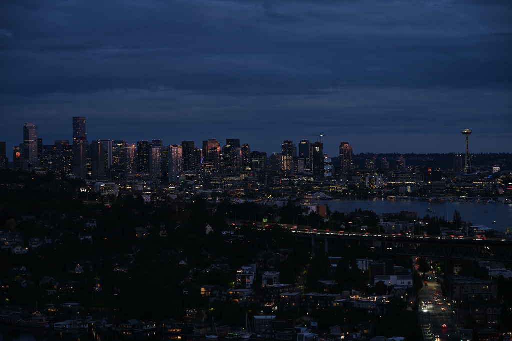

**Data Preparation**

## Part 1 — Data Source

I used daily weather records from NOAA Seattle Sand Point (`USW00094290`). The requested period is January 1, 2015 through December 31, 2025. The CSV was requested in metric units.

This is a single-station weather dataset, not a dataset of observed flooding.

## Part 2 — Load the Data

```python
import pandas as pd

weather_raw = pd.read_csv(
    "Data/Raw/seattle_sand_point_2015_2025.csv"
)

weather_raw.head()
```

|  | STATION | NAME | LATITUDE | LONGITUDE | ELEVATION | DATE | PRCP | PRCP_ATTRIBUTES | SNOW | SNOW_ATTRIBUTES | SNWD | SNWD_ATTRIBUTES | TAVG | TAVG_ATTRIBUTES | TMAX | TMAX_ATTRIBUTES | TMIN | TMIN_ATTRIBUTES |
| --- | --- | --- | --- | --- | --- | --- | --- | --- | --- | --- | --- | --- | --- | --- | --- | --- | --- | --- |
| 0 | USW00094290 | SEATTLE SAND POINT WEATHER FORECAST OFFICE, WA US | 47.6872 | -122.2553 | 18.3 | 2015-01-01 | 0.0 | ,,W,2400 | 0.0 | ,,W, | 0.0 | ,,W, | NaN | NaN | 7.2 | ,,W | -2.1 | ,,W |
| 1 | USW00094290 | SEATTLE SAND POINT WEATHER FORECAST OFFICE, WA US | 47.6872 | -122.2553 | 18.3 | 2015-01-02 | 0.5 | ,,W,2400 | 0.0 | ,,W, | 0.0 | ,,W, | NaN | NaN | 5.6 | ,,W | 0.0 | ,,W |
| 2 | USW00094290 | SEATTLE SAND POINT WEATHER FORECAST OFFICE, WA US | 47.6872 | -122.2553 | 18.3 | 2015-01-03 | 0.5 | ,,W,2400 | 0.0 | ,,W, | 0.0 | ,,W, | NaN | NaN | 5.6 | ,,W | 2.2 | ,,W |
| 3 | USW00094290 | SEATTLE SAND POINT WEATHER FORECAST OFFICE, WA US | 47.6872 | -122.2553 | 18.3 | 2015-01-04 | 5.1 | ,,W,2400 | 0.0 | ,,W, | 0.0 | ,,W, | NaN | NaN | 11.1 | ,,W | 3.9 | ,,W |
| 4 | USW00094290 | SEATTLE SAND POINT WEATHER FORECAST OFFICE, WA US | 47.6872 | -122.2553 | 18.3 | 2015-01-05 | 6.6 | ,,W,2400 | 0.0 | ,,W, | 0.0 | ,,W, | NaN | NaN | 12.8 | ,,W | 11.1 | ,,W |

## Part 3 — Initial Data Inspection

Inspect the data before changing any values.

### 3.1 Dataset Dimensions

```python
weather_raw.shape
```

```
(3989, 18)
```

### 3.2 Column Names

```python
weather_raw.columns
```

```
Index(['STATION', 'NAME', 'LATITUDE', 'LONGITUDE', 'ELEVATION', 'DATE', 'PRCP',
       'PRCP_ATTRIBUTES', 'SNOW', 'SNOW_ATTRIBUTES', 'SNWD', 'SNWD_ATTRIBUTES',
       'TAVG', 'TAVG_ATTRIBUTES', 'TMAX', 'TMAX_ATTRIBUTES', 'TMIN',
       'TMIN_ATTRIBUTES'],
      dtype='object')
```

### 3.3 Data Types

```python
weather_raw.info()
```

```
<class 'pandas.core.frame.DataFrame'>
RangeIndex: 3989 entries, 0 to 3988
Data columns (total 18 columns):
 #   Column           Non-Null Count  Dtype
---  ------           --------------  -----
 0   STATION          3989 non-null   object
 1   NAME             3989 non-null   object
 2   LATITUDE         3989 non-null   float64
 3   LONGITUDE        3989 non-null   float64
 4   ELEVATION        3989 non-null   float64
 5   DATE             3989 non-null   object
 6   PRCP             3987 non-null   float64
 7   PRCP_ATTRIBUTES  3987 non-null   object
 8   SNOW             3989 non-null   float64
 9   SNOW_ATTRIBUTES  3989 non-null   object
 10  SNWD             3989 non-null   float64
 11  SNWD_ATTRIBUTES  3989 non-null   object
 12  TAVG             0 non-null      float64
 13  TAVG_ATTRIBUTES  0 non-null      float64
 14  TMAX             3985 non-null   float64
 15  TMAX_ATTRIBUTES  3985 non-null   object
 16  TMIN             3981 non-null   float64
 17  TMIN_ATTRIBUTES  3981 non-null   object
dtypes: float64(10), object(8)
memory usage: 561.1+ KB
```

### 3.4 Missing Values

```python
weather_raw.isna().sum()
```

```
STATION               0
NAME                  0
LATITUDE              0
LONGITUDE             0
ELEVATION             0
DATE                  0
PRCP                  2
PRCP_ATTRIBUTES       2
SNOW                  0
SNOW_ATTRIBUTES       0
SNWD                  0
SNWD_ATTRIBUTES       0
TAVG               3989
TAVG_ATTRIBUTES    3989
TMAX                  4
TMAX_ATTRIBUTES       4
TMIN                  8
TMIN_ATTRIBUTES       8
dtype: int64
```

### 3.5 Date Range

```python
print(
    "First date:",
    weather_raw["DATE"].min()
)

print(
    "Last date:",
    weather_raw["DATE"].max()
)
```

```
First date: 2015-01-01
Last date: 2025-12-31
```

### 3.6 Number of Stations

```python
weather_raw[
    "STATION"
].nunique()
```

```
1
```

### 3.7 Duplicate Rows

```python
weather_raw.duplicated().sum()
```

```
0
```

### 3.8 Duplicate Station-Date Records

Two records can have the same station and date without being identical rows.

```python
weather_raw.duplicated(
    subset=[
        "STATION",
        "DATE"
    ]
).sum()
```

```
0
```

### 3.9 Precipitation Summary

```python
weather_raw[
    "PRCP"
].describe()
```

```
count    3987.000000
mean        2.722573
std         5.815001
min         0.000000
25%         0.000000
50%         0.000000
75%         2.800000
max        67.100000
Name: PRCP, dtype: float64
```

### 3.10 Missing Dates

Compare the recorded dates with the requested calendar.

```python
study_start = pd.Timestamp(
    "2015-01-01"
)

study_end = pd.Timestamp(
    "2025-12-31"
)

raw_dates = pd.to_datetime(
    weather_raw["DATE"],
    format="%Y-%m-%d"
)

if raw_dates.isna().any():
    raise ValueError(
        "A date is missing. Review the source file."
    )

full_date_range = pd.date_range(
    study_start,
    study_end,
    freq="D"
)

missing_dates = (
    full_date_range.difference(
        raw_dates
    )
)

print(
    "Missing dates:",
    len(
        missing_dates
    )
)

missing_dates
```

```
Missing dates: 29
```

```
DatetimeIndex(['2023-06-01', '2023-06-02', '2023-06-03', '2023-06-04',
               '2023-06-05', '2023-06-06', '2023-06-07', '2023-06-08',
               '2023-06-09', '2023-06-10', '2023-06-11', '2023-06-12',
               '2023-06-13', '2023-06-14', '2023-06-15', '2023-06-16',
               '2023-06-17', '2023-06-18', '2023-06-19', '2023-06-20',
               '2023-06-21', '2023-06-22', '2023-06-23', '2023-06-24',
               '2023-06-25', '2023-06-26', '2023-06-27', '2023-06-28',
               '2023-06-29'],
              dtype='datetime64[ns]', freq=None)
```

### 3.11 Missing Precipitation Observations

```python
missing_prcp = (
    weather_raw[
        "PRCP"
    ].isna()
)

weather_raw.loc[
    missing_prcp,
    [
        "DATE",
        "PRCP",
        "PRCP_ATTRIBUTES"
    ]
]
```

|  | DATE | PRCP | PRCP_ATTRIBUTES |
| --- | --- | --- | --- |
| 3713 | 2025-03-31 | NaN | NaN |
| 3714 | 2025-04-01 | NaN | NaN |

### 3.12 Inspection Findings

The source contains 3,989 records and no duplicate rows or station-date keys.

Two recorded dates have missing precipitation values.

Another 29 dates, June 1–29, 2023, are absent from the file entirely.

Missing rainfall is not zero rainfall. The file does not establish why these observations are missing.

## Part 4 — Data Cleaning

`weather_raw` is the original in-memory table.

`weather` is a separate working copy.

Neither the raw table nor the source CSV is overwritten.

### 4.1 Create a Working Copy

```python
weather = weather_raw.copy()
```

### 4.2 Convert Date to Datetime

```python
weather[
    "DATE"
] = raw_dates

weather[
    "DATE"
].dtype
```

```
dtype('<M8[ns]')
```

### 4.3 Validate the Station-Date Structure

```python
if weather[
    "STATION"
].isna().any():
    raise ValueError(
        "A station ID is missing."
    )

if weather[
    "STATION"
].nunique() != 1:
    raise ValueError(
        "This procedure is for one station only."
    )

if weather.duplicated(
    subset=[
        "STATION",
        "DATE"
    ]
).any():
    raise ValueError(
        "Resolve duplicate station-date records first."
    )

if weather[
    "DATE"
].min() < study_start:
    raise ValueError(
        "A date is earlier than the study period."
    )

if weather[
    "DATE"
].max() > study_end:
    raise ValueError(
        "A date is later than the study period."
    )

weather = weather.sort_values(
    "DATE"
)

weather = weather.reset_index(
    drop=True
)
```

### 4.4 Remove Empty Variables

Removed `TAVG` and its attributes only after confirming that they are entirely missing.

```python
empty_columns = [
    "TAVG",
    "TAVG_ATTRIBUTES"
]

for column in empty_columns:

    if weather[
        column
    ].notna().any():

        raise ValueError(
            "This column is not entirely empty: "
            + column
        )

weather = weather.drop(
    columns=empty_columns
)
```

### 4.5 Restore Missing Calendar Dates

`reindex` adds absent dates but does not create rainfall measurements.

```python
weather = weather.set_index(
    "DATE"
)

weather = weather.reindex(
    full_date_range
)

weather.index.name = "DATE"

weather = weather.reset_index()

weather[
    "ROW_MISSING"
] = weather[
    "DATE"
].isin(
    missing_dates
)
```

### 4.6 Restore Station Metadata

Fill only station metadata that have one known value in this export.

Do not fill weather measurements or observation attributes.

```python
station_columns = [
    "STATION",
    "NAME",
    "LATITUDE",
    "LONGITUDE",
    "ELEVATION"
]

for column in station_columns:

    known_values = (
        weather_raw[
            column
        ]
        .dropna()
        .unique()
    )

    if len(
        known_values
    ) != 1:

        raise ValueError(
            "Review station metadata: "
            + column
        )

    station_value = (
        known_values[0]
    )

    weather[
        column
    ] = weather[
        column
    ].fillna(
        station_value
    )
```

### 4.7 Flag Missing Precipitation

```python
weather[
    "PRCP_MISSING"
] = weather[
    "PRCP"
].isna()

weather[
    "PRCP_MISSING"
].value_counts()
```

```
PRCP_MISSING
False    3987
True       31
Name: count, dtype: int64
```

```python
pd.crosstab(
    weather[
        "ROW_MISSING"
    ],
    weather[
        "PRCP_MISSING"
    ]
)
```

| PRCP_MISSING ROW_MISSING | False | True |
| --- | --- | --- |
| False | 3987 | 2 |
| True | 0 | 29 |

### 4.8 Verify the Cleaned Time Series

```python
print(
    "First date:",
    weather[
        "DATE"
    ].min()
)

print(
    "Last date:",
    weather[
        "DATE"
    ].max()
)

print(
    "Calendar days:",
    len(
        full_date_range
    )
)

print(
    "Rows after cleaning:",
    len(
        weather
    )
)

print(
    "Duplicate dates:",
    weather[
        "DATE"
    ].duplicated().sum()
)

print(
    "Inserted dates:",
    weather[
        "ROW_MISSING"
    ].sum()
)

weather.isna().sum()
```

```
First date: 2015-01-01 00:00:00
Last date: 2025-12-31 00:00:00
Calendar days: 4018
Rows after cleaning: 4018
Duplicate dates: 0
Inserted dates: 29
```

```
DATE                0
STATION             0
NAME                0
LATITUDE            0
LONGITUDE           0
ELEVATION           0
PRCP               31
PRCP_ATTRIBUTES    31
SNOW               29
SNOW_ATTRIBUTES    29
SNWD               29
SNWD_ATTRIBUTES    29
TMAX               33
TMAX_ATTRIBUTES    33
TMIN               37
TMIN_ATTRIBUTES    37
ROW_MISSING         0
PRCP_MISSING        0
dtype: int64
```

## Part 5 — Quality-Flag Review

The NOAA attributes contain the measurement flag first and the quality flag second.

Quality flag `I` means an internal-consistency check failed; it does not provide a replacement value.[^1]

### 5.1 Read the Quality Flags

```python
variables = [
    "PRCP",
    "TMAX",
    "TMIN",
    "SNOW",
    "SNWD"
]

quality_flags = pd.DataFrame(
    index=weather.index
)

for variable in variables:

    attribute_column = (
        variable
        + "_ATTRIBUTES"
    )

    attributes = weather[
        attribute_column
    ].astype(
        "string"
    )

    parts = attributes.str.split(
        ","
    )

    quality_flag = (
        parts.str[1]
    )

    quality_flag = (
        quality_flag.str.strip()
    )

    observed_rows = weather[
        variable
    ].notna()

    if quality_flag[
        observed_rows
    ].isna().any():

        raise ValueError(
            "Review the attributes for "
            + variable
        )

    quality_flags[
        variable
    ] = quality_flag
```

### 5.2 List Flagged Observations

```python
for variable in variables:

    quality_flag = quality_flags[
        variable
    ]

    flagged_rows = (
        quality_flag.fillna("")
        != ""
    )

    columns_to_show = [
        "DATE",
        variable,
        variable + "_ATTRIBUTES"
    ]

    print(
        "\nVariable:",
        variable
    )

    if flagged_rows.sum() == 0:

        print(
            "No nonblank quality flags."
        )

    else:

        flagged_values = weather.loc[
            flagged_rows,
            columns_to_show
        ]

        print(
            flagged_values.to_string(
                index=False
            )
        )
```

```
Variable: PRCP
No nonblank quality flags.

Variable: TMAX
      DATE  TMAX TMAX_ATTRIBUTES
2024-10-18  10.6            ,I,W

Variable: TMIN
      DATE  TMIN TMIN_ATTRIBUTES
2024-10-19  12.8            ,I,W

Variable: SNOW
      DATE  SNOW SNOW_ATTRIBUTES
2017-12-25  36.0           ,I,W,

Variable: SNWD
      DATE  SNWD SNWD_ATTRIBUTES
2017-12-24   0.0           ,I,W,
2017-12-25 510.0           ,I,W,
```

### 5.3 Inspect Trace Precipitation

Measurement flag `T` means trace precipitation, not a missing measurement or a quality exclusion.[^2]

```python
attributes = weather[
    "PRCP_ATTRIBUTES"
].astype(
    "string"
)

parts = attributes.str.split(
    ","
)

prcp_measurement_flag = (
    parts.str[0]
)

prcp_measurement_flag = (
    prcp_measurement_flag.str.strip()
)

prcp_measurement_flag = (
    prcp_measurement_flag.astype(
        "string"
    )
)

trace_days = (
    prcp_measurement_flag
    == "T"
)

print(
    "Trace precipitation records:",
    trace_days.sum()
)

weather.loc[
    trace_days.fillna(
        False
    ),
    [
        "DATE",
        "PRCP",
        "PRCP_ATTRIBUTES"
    ]
].head()
```

```
Trace precipitation records: 92
```

|  | DATE | PRCP | PRCP_ATTRIBUTES |
| --- | --- | --- | --- |
| 1388 | 2018-10-20 | 0.0 | T,,W,2400 |
| 1389 | 2018-10-21 | 0.0 | T,,W,2400 |
| 1390 | 2018-10-22 | 0.0 | T,,W,2400 |
| 1392 | 2018-10-24 | 0.0 | T,,W,2400 |
| 1397 | 2018-10-29 | 0.0 | T,,W,2400 |

## Part 6 — Finalize the Cleaned Dataset

### 6.1 Quality-Control Policy

The first-version rule excludes measurements with nonblank quality flags.

Only the affected values become missing; entire dates are not deleted.

This is a conservative analysis choice, not proof that every flagged value is wrong.[^3]

### 6.2 Apply Quality Flags

```python
weather_clean = (
    weather.copy()
)

qc_summary = pd.DataFrame(
    index=variables
)

qc_summary.index.name = (
    "Variable"
)

qc_summary[
    "Missing before QC"
] = weather[
    variables
].isna().sum()

qc_summary[
    "Excluded by QC"
] = 0

for variable in variables:

    quality_flag = (
        quality_flags[
            variable
        ]
    )

    has_quality_flag = (
        quality_flag.fillna("")
        != ""
    )

    has_value = (
        weather[
            variable
        ].notna()
    )

    excluded = (
        has_quality_flag
        & has_value
    )

    weather_clean[
        variable
        + "_QC_EXCLUDED"
    ] = excluded

    weather_clean.loc[
        has_quality_flag,
        variable
    ] = float(
        "nan"
    )

    qc_summary.loc[
        variable,
        "Excluded by QC"
    ] = excluded.sum()

qc_summary[
    "Missing after QC"
] = weather_clean[
    variables
].isna().sum()

qc_summary
```

| Variable | Missing before QC | Excluded by QC | Missing after QC |
| --- | --- | --- | --- |
| PRCP | 31 | 0 | 31 |
| TMAX | 33 | 1 | 34 |
| TMIN | 37 | 1 | 38 |
| SNOW | 29 | 1 | 30 |
| SNWD | 29 | 2 | 31 |

### 6.3 Preserve Trace and Missingness Information

```python
weather_clean[
    "PRCP_TRACE"
] = trace_days

weather_clean[
    "PRCP_MISSING"
] = weather_clean[
    "PRCP"
].isna()

weather_clean[
    "PRCP_TRACE"
].value_counts(
    dropna=False
)
```

```
PRCP_TRACE
False    3895
True       92
<NA>       31
Name: count, dtype: Int64
```

### 6.4 Basic Physical Checks

Check the negative precipitation and snow amounts, inconsistent daily minimum/maximum temperatures, and infinite values.

Large rainfall values are not removed merely because they are unusual.

```python
negative_prcp = (
    weather_clean[
        "PRCP"
    ]
    < 0
).sum()

negative_snow = (
    weather_clean[
        "SNOW"
    ]
    < 0
).sum()

negative_snwd = (
    weather_clean[
        "SNWD"
    ]
    < 0
).sum()

bad_temperatures = (
    weather_clean[
        "TMIN"
    ]
    > weather_clean[
        "TMAX"
    ]
).sum()

infinite_values = 0

for variable in variables:

    positive_inf = (
        weather_clean[
            variable
        ]
        == float(
            "inf"
        )
    ).sum()

    negative_inf = (
        weather_clean[
            variable
        ]
        == float(
            "-inf"
        )
    ).sum()

    infinite_values = (
        infinite_values
        + positive_inf
        + negative_inf
    )

physical_checks = pd.DataFrame()

physical_checks[
    "Check"
] = [
    "Negative PRCP",
    "Negative SNOW",
    "Negative SNWD",
    "TMIN greater than TMAX",
    "Infinite measurements"
]

physical_checks[
    "Count"
] = [
    negative_prcp,
    negative_snow,
    negative_snwd,
    bad_temperatures,
    infinite_values
]

physical_checks
```

|  | Check | Count |
| --- | --- | --- |
| 0 | Negative PRCP | 0 |
| 1 | Negative SNOW | 0 |
| 2 | Negative SNWD | 0 |
| 3 | TMIN greater than TMAX | 0 |
| 4 | Infinite measurements | 0 |

```python
if physical_checks[
    "Count"
].sum() != 0:

    raise ValueError(
        "Review the physical checks before saving."
    )

print(
    "Basic physical checks passed."
)
```

```
Basic physical checks passed.
```

### 6.5 Units and Column Definitions

The original measurement names and metric units are retained.[^4]

| Column | Meaning | Unit or coding |
| --- | --- | --- |
| `PRCP` | Daily precipitation | mm |
| `TMAX`, `TMIN` | Daily maximum/minimum temperature | degrees Celsius |
| `SNOW`, `SNWD` | Snowfall / snow depth | mm |
| `ROW_MISSING` | Date absent from source CSV | True / False |
| `PRCP_MISSING` | Precipitation unavailable after QC | True / False |
| `PRCP_TRACE` | Recorded trace flag | True / False / missing |
| `*_QC_EXCLUDED` | Existing value excluded by QC rule | True / False |
| `*_ATTRIBUTES` | Original observation attributes | Unchanged text |

### 6.6 Save the Cleaned Dataset

```python
from pathlib import Path

processed_dir = Path(
    "Data/Processed"
)

processed_dir.mkdir(
    parents=True,
    exist_ok=True
)

output_path = (
    "Data/Processed/"
    "seattle_sand_point_cleaned_2015_2025.csv"
)

weather_clean.to_csv(
    output_path,
    index=False,
    date_format="%Y-%m-%d",
    na_rep="",
    encoding="utf-8"
)

print(
    "Saved:",
    output_path
)

print(
    "Rows:",
    len(
        weather_clean
    )
)

print(
    "Columns:",
    weather_clean.shape[1]
)
```

```
Saved: Data/Processed/seattle_sand_point_cleaned_2015_2025.csv
Rows: 4018
Columns: 24
```

## Part 7 — Exploratory Data Analysis

This section examines data coverage, daily precipitation, its distribution, and seasonal differences.

It describes one station during 2015–2025, not observed flood events.

### 7.1 Prepare the EDA Data

```python
import matplotlib.pyplot as plt

eda = weather_clean[
    [
        "DATE",
        "PRCP"
    ]
].copy()

eda = eda.sort_values(
    "DATE"
)

eda[
    "YEAR"
] = eda[
    "DATE"
].dt.year

eda[
    "MONTH"
] = eda[
    "DATE"
].dt.month

if eda[
    "PRCP"
].notna().sum() == 0:

    raise ValueError(
        "No precipitation observations are available for EDA."
    )
```

### 7.2 Check Monthly Coverage Before Calculating Totals

A month is included in monthly-total comparisons only if every day has a retained precipitation value.

Available days from incomplete months remain in the daily analysis.

```python
monthly_groups = (
    eda.groupby(
        [
            "YEAR",
            "MONTH"
        ]
    )
)

monthly = pd.DataFrame()

monthly[
    "expected_days"
] = monthly_groups.size()

monthly[
    "observed_days"
] = monthly_groups[
    "PRCP"
].count()

monthly[
    "observed_sum_mm"
] = monthly_groups[
    "PRCP"
].sum(
    min_count=1
)

monthly = monthly.reset_index()

monthly[
    "missing_days"
] = (
    monthly[
        "expected_days"
    ]
    - monthly[
        "observed_days"
    ]
)

monthly[
    "coverage_pct"
] = (
    100
    * monthly[
        "observed_days"
    ]
    / monthly[
        "expected_days"
    ]
)

monthly[
    "complete"
] = (
    monthly[
        "observed_days"
    ]
    == monthly[
        "expected_days"
    ]
)

monthly[
    "total_mm"
] = monthly[
    "observed_sum_mm"
]

incomplete_months = (
    monthly[
        "complete"
    ]
    == False
)

monthly.loc[
    incomplete_months,
    "total_mm"
] = float(
    "nan"
)

coverage_columns = [
    "YEAR",
    "MONTH",
    "expected_days",
    "observed_days",
    "missing_days",
    "coverage_pct"
]

monthly.loc[
    incomplete_months,
    coverage_columns
].round(
    2
)
```

|  | YEAR | MONTH | expected_days | observed_days | missing_days | coverage_pct |
| --- | --- | --- | --- | --- | --- | --- |
| 101 | 2023 | 6 | 30 | 1 | 29 | 3.33 |
| 122 | 2025 | 3 | 31 | 30 | 1 | 96.77 |
| 123 | 2025 | 4 | 30 | 29 | 1 | 96.67 |

### 7.3 Daily Precipitation Through Time

Missing values remain gaps.

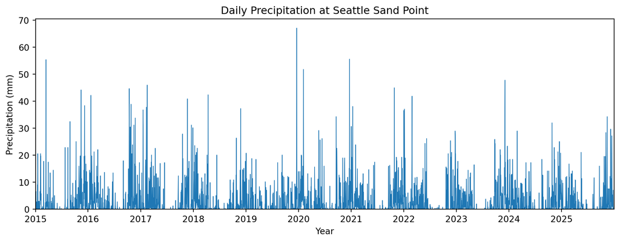

Figure 1: Daily precipitation at Seattle Sand Point, 2015–2025. Missing values remain gaps.

```python
plt.figure(
    figsize=(
        10,
        4
    )
)

plt.plot(
    eda[
        "DATE"
    ],
    eda[
        "PRCP"
    ],
    linewidth=0.7
)

plt.title(
    "Daily Precipitation at Seattle Sand Point"
)

plt.xlabel(
    "Year"
)

plt.ylabel(
    "Precipitation (mm)"
)

plt.xlim(
    study_start,
    study_end
)

plt.ylim(
    bottom=0
)

plt.tight_layout()

plt.show()
```

### 7.4 Distribution of Daily Precipitation

Missing values are excluded only from this numerical summary and histogram.

Reported zeros include trace observations.[^5]

```python
observed_prcp = (
    eda[
        "PRCP"
    ].dropna()
)

prcp_summary = (
    observed_prcp.describe(
        percentiles=[
            0.50,
            0.90,
            0.95,
            0.99
        ]
    )
)

prcp_summary.round(
    2
)
```

```
count    3987.00
mean        2.72
std         5.82
min         0.00
50%         0.00
90%         9.10
95%        14.00
99%        27.97
max        67.10
Name: PRCP, dtype: float64
```

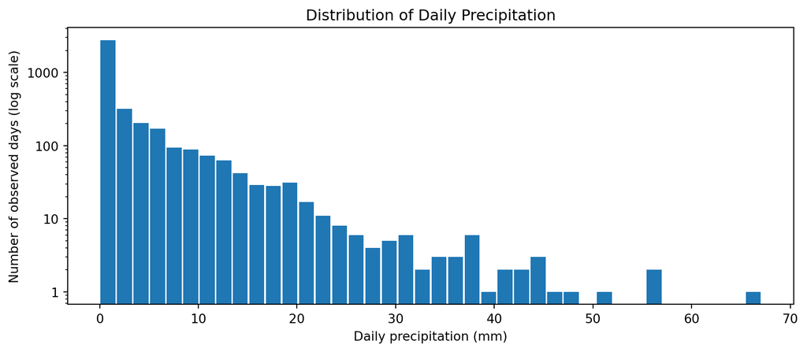

Figure 2: Distribution of all available daily precipitation amounts. The frequency axis uses a logarithmic scale.

```python
plt.figure(
    figsize=(
        9,
        4
    )
)

plt.hist(
    observed_prcp,
    bins=40,
    rwidth=0.9,
    log=True
)

plt.title(
    "Distribution of Daily Precipitation"
)

plt.xlabel(
    "Daily precipitation (mm)"
)

plt.ylabel(
    "Number of observed days (log scale)"
)

plt.yticks(
    [
        1,
        10,
        100,
        1000
    ],
    [
        "1",
        "10",
        "100",
        "1000"
    ]
)

plt.tight_layout()

plt.show()
```

### 7.5 Seasonal Pattern from Complete Months

```python
month_groups = (
    monthly.groupby(
        "MONTH"
    )[
        "total_mm"
    ]
)

seasonal = pd.DataFrame(
    index=range(
        1,
        13
    )
)

seasonal[
    "complete_months"
] = month_groups.count()

seasonal[
    "mean_total_mm"
] = month_groups.mean()

seasonal[
    "median_total_mm"
] = month_groups.median()

month_names = [
    "Jan",
    "Feb",
    "Mar",
    "Apr",
    "May",
    "Jun",
    "Jul",
    "Aug",
    "Sep",
    "Oct",
    "Nov",
    "Dec"
]

seasonal.index = (
    month_names
)

seasonal.index.name = (
    "Month"
)

seasonal.round(
    2
)
```

| Month | complete_months | mean_total_mm | median_total_mm |
| --- | --- | --- | --- |
| Jan | 11 | 137.52 | 161.20 |
| Feb | 11 | 108.33 | 101.40 |
| Mar | 10 | 91.35 | 80.95 |
| Apr | 10 | 66.89 | 58.95 |
| May | 11 | 52.51 | 41.50 |
| Jun | 10 | 37.97 | 38.60 |
| Jul | 11 | 9.16 | 4.30 |
| Aug | 11 | 22.21 | 12.30 |
| Sep | 11 | 50.68 | 35.90 |
| Oct | 11 | 103.56 | 94.70 |
| Nov | 11 | 146.92 | 137.60 |
| Dec | 11 | 163.48 | 168.20 |

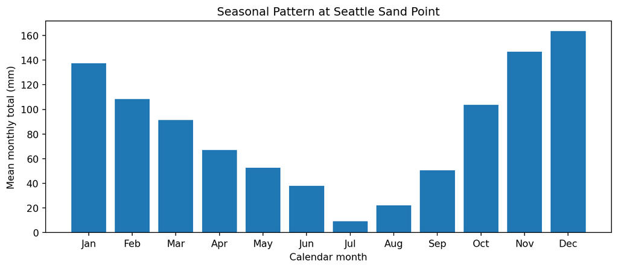

Figure 3: Mean monthly precipitation totals from complete months only.

```python
plt.figure(
    figsize=(
        9,
        4
    )
)

plt.bar(
    seasonal.index,
    seasonal[
        "mean_total_mm"
    ]
)

plt.title(
    "Seasonal Pattern at Seattle Sand Point"
)

plt.xlabel(
    "Calendar month"
)

plt.ylabel(
    "Mean monthly total (mm)"
)

plt.tight_layout()

plt.show()
```

### 7.6 Interpretation Boundaries

These summaries describe this station sample, not precipitation at every Seattle location.

Missing measurements have not been estimated.

Large daily rainfall is not itself evidence of flooding.

These plots do not establish flood occurrence, flood mechanisms, or long-term climate trends.

### 7.7 EDA Findings

Among the 3,987 available daily precipitation records, the mean is about 2.72 mm, the median is 0 mm, and the maximum is 67.1 mm.

The distribution is strongly right-skewed.

The complete-month comparison uses 129 of the 132 year-months.

December has the highest sample mean monthly total, about 163.48 mm, while July has the lowest, about 9.16 mm.

These are descriptive results for this station and study period.

## Part 8 — Rainfall Feature Engineering

### 8.1 Define the Time Convention

Let $P_t$ be the reported precipitation for date $t$.

We construct:

$$R_{1,t}
=
P_{t-1}$$

$$R_{3,t}
=
P_{t-1}
+
P_{t-2}
+
P_{t-3}$$

$$R_{7,t}
=
\sum_{i=1}^{7}
P_{t-i}$$

These features exclude $P_t$.

The provisional prediction convention is to use observations through date $t-1$ when predicting an outcome labeled date $t$.

The 1-, 3-, and 7-day windows are starting choices, not proven optimal hydrologic windows.

### 8.2 Prepare the Feature Table

```python
features = weather_clean[
    [
        "STATION",
        "DATE",
        "PRCP"
    ]
].copy()

features = features.sort_values(
    "DATE"
)

features = features.reset_index(
    drop=True
)

expected_dates = pd.Series(
    full_date_range
)

if not features[
    "DATE"
].equals(
    expected_dates
):

    raise ValueError(
        "Keep one row per calendar day before creating features."
    )
```

### 8.3 Previous-Day Precipitation

With the complete daily calendar, shifting values down one row places the previous day’s precipitation beside the current date. The dates themselves stay unchanged.[^6]

```python
features[
    "RAIN_PREV_1D_MM"
] = features[
    "PRCP"
].shift(
    1
)

features[
    [
        "DATE",
        "PRCP",
        "RAIN_PREV_1D_MM"
    ]
].head(
    10
)
```

|  | DATE | PRCP | RAIN_PREV_1D_MM |
| --- | --- | --- | --- |
| 0 | 2015-01-01 | 0.0 | NaN |
| 1 | 2015-01-02 | 0.5 | 0.0 |
| 2 | 2015-01-03 | 0.5 | 0.5 |
| 3 | 2015-01-04 | 5.1 | 0.5 |
| 4 | 2015-01-05 | 6.6 | 5.1 |
| 5 | 2015-01-06 | 0.0 | 6.6 |
| 6 | 2015-01-07 | 0.0 | 0.0 |
| 7 | 2015-01-08 | 0.0 | 0.0 |
| 8 | 2015-01-09 | 0.0 | 0.0 |
| 9 | 2015-01-10 | 2.8 | 0.0 |

### 8.4 Previous Three-Day Precipitation

Apply the rolling sum to the already shifted precipitation series.

`min_periods=3` requires all three calendar-day values to be available; otherwise the feature remains missing.[^7]

```python
previous_rain = (
    features[
        "RAIN_PREV_1D_MM"
    ]
)

window_3d = (
    previous_rain.rolling(
        window=3,
        min_periods=3
    )
)

features[
    "RAIN_PREV_3D_MM"
] = window_3d.sum()
```

### 8.5 Previous Seven-Day Precipitation

The seven-day feature uses the same shifted rainfall series and requires all seven previous calendar-day values to be available.[^8]

```python
window_7d = (
    previous_rain.rolling(
        window=7,
        min_periods=7
    )
)

features[
    "RAIN_PREV_7D_MM"
] = window_7d.sum()

display_columns = [
    "DATE",
    "PRCP",
    "RAIN_PREV_1D_MM",
    "RAIN_PREV_3D_MM",
    "RAIN_PREV_7D_MM"
]

features[
    display_columns
].head(
    10
)
```

|  | DATE | PRCP | RAIN_PREV_1D_MM | RAIN_PREV_3D_MM | RAIN_PREV_7D_MM |
| --- | --- | --- | --- | --- | --- |
| 0 | 2015-01-01 | 0.0 | NaN | NaN | NaN |
| 1 | 2015-01-02 | 0.5 | 0.0 | NaN | NaN |
| 2 | 2015-01-03 | 0.5 | 0.5 | NaN | NaN |
| 3 | 2015-01-04 | 5.1 | 0.5 | 1.0 | NaN |
| 4 | 2015-01-05 | 6.6 | 5.1 | 6.1 | NaN |
| 5 | 2015-01-06 | 0.0 | 6.6 | 12.2 | NaN |
| 6 | 2015-01-07 | 0.0 | 0.0 | 11.7 | NaN |
| 7 | 2015-01-08 | 0.0 | 0.0 | 6.6 | 12.7 |
| 8 | 2015-01-09 | 0.0 | 0.0 | 0.0 | 12.7 |
| 9 | 2015-01-10 | 2.8 | 0.0 | 0.0 | 12.2 |

For January 8, 2015, the three-day feature uses January 5–7 and the seven-day feature uses January 1–7.

Neither includes January 8.

### 8.6 Visualize the Rainfall-History Features

To make the feature construction easier to interpret, we display a short example period rather than the entire 2015–2025 record.

The 1-day feature represents precipitation on the previous calendar day.

The 3-day and 7-day features accumulate precipitation over progressively longer histories.

All three exclude precipitation reported for the target date itself.

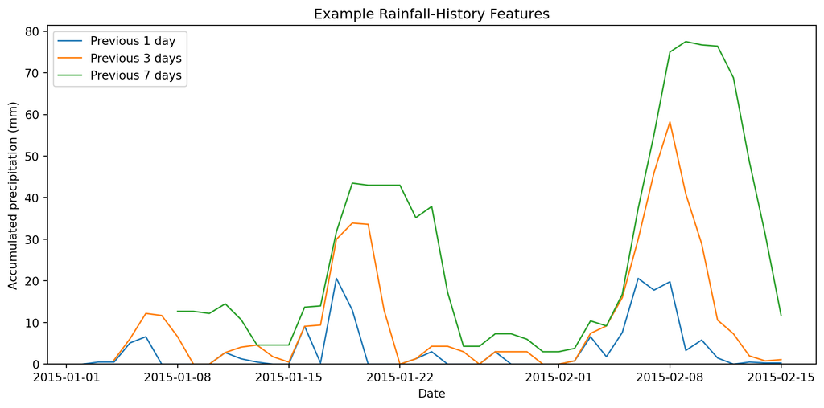

Figure 4: Example of previous 1-, 3-, and 7-day rainfall-history features at Seattle Sand Point. Each feature uses precipitation before the date shown.

```python
feature_plot_start = pd.Timestamp(
    "2015-01-01"
)

feature_plot_end = pd.Timestamp(
    "2015-02-15"
)

feature_plot_rows = (
    features[
        "DATE"
    ].between(
        feature_plot_start,
        feature_plot_end
    )
)

feature_plot = (
    features.loc[
        feature_plot_rows,
        [
            "DATE",
            "RAIN_PREV_1D_MM",
            "RAIN_PREV_3D_MM",
            "RAIN_PREV_7D_MM"
        ]
    ].copy()
)

plt.figure(
    figsize=(
        10,
        5
    )
)

plt.plot(
    feature_plot[
        "DATE"
    ],
    feature_plot[
        "RAIN_PREV_1D_MM"
    ],
    label="Previous 1 day",
    linewidth=1.2
)

plt.plot(
    feature_plot[
        "DATE"
    ],
    feature_plot[
        "RAIN_PREV_3D_MM"
    ],
    label="Previous 3 days",
    linewidth=1.2
)

plt.plot(
    feature_plot[
        "DATE"
    ],
    feature_plot[
        "RAIN_PREV_7D_MM"
    ],
    label="Previous 7 days",
    linewidth=1.2
)

plt.title(
    "Example Rainfall-History Features"
)

plt.xlabel(
    "Date"
)

plt.ylabel(
    "Accumulated precipitation (mm)"
)

plt.ylim(
    bottom=0
)

plt.legend()

plt.tight_layout()

plt.show()
```

The longer windows are smoother because each value contains rainfall from multiple preceding calendar days.

A large seven-day value therefore does not mean that all precipitation occurred on the date shown.

The first rows are missing by design because the study period does not contain enough earlier observations to construct complete histories.

### 8.7 Check Feature Availability

A feature can be missing because the study begins without enough previous history or because one of the required precipitation observations is missing.

```python
feature_columns = [
    "RAIN_PREV_1D_MM",
    "RAIN_PREV_3D_MM",
    "RAIN_PREV_7D_MM"
]

feature_summary = pd.DataFrame(
    index=feature_columns
)

feature_summary.index.name = (
    "Feature"
)

feature_summary[
    "Available days"
] = features[
    feature_columns
].count()

feature_summary[
    "Missing days"
] = features[
    feature_columns
].isna().sum()

feature_summary
```

| Feature | Available days | Missing days |
| --- | --- | --- |
| RAIN_PREV_1D_MM | 3986 | 32 |
| RAIN_PREV_3D_MM | 3980 | 38 |
| RAIN_PREV_7D_MM | 3968 | 50 |

### 8.8 Inspect the Effect of the June 2023 Gap

```python
gap_example = (
    features[
        "DATE"
    ].between(
        "2023-06-28",
        "2023-07-08"
    )
)

features.loc[
    gap_example,
    display_columns
]
```

|  | DATE | PRCP | RAIN_PREV_1D_MM | RAIN_PREV_3D_MM | RAIN_PREV_7D_MM |
| --- | --- | --- | --- | --- | --- |
| 3100 | 2023-06-28 | NaN | NaN | NaN | NaN |
| 3101 | 2023-06-29 | NaN | NaN | NaN | NaN |
| 3102 | 2023-06-30 | 0.0 | NaN | NaN | NaN |
| 3103 | 2023-07-01 | 0.0 | 0.0 | NaN | NaN |
| 3104 | 2023-07-02 | 0.0 | 0.0 | NaN | NaN |
| 3105 | 2023-07-03 | 0.0 | 0.0 | 0.0 | NaN |
| 3106 | 2023-07-04 | 0.0 | 0.0 | 0.0 | NaN |
| 3107 | 2023-07-05 | 0.0 | 0.0 | 0.0 | NaN |
| 3108 | 2023-07-06 | 0.0 | 0.0 | 0.0 | NaN |
| 3109 | 2023-07-07 | 0.0 | 0.0 | 0.0 | 0.0 |
| 3110 | 2023-07-08 | 0.0 | 0.0 | 0.0 | 0.0 |

No rainfall values are filled with zero to create complete windows.

### 8.9 Save the Candidate Features

```python
feature_path = (
    "Data/Processed/"
    "seattle_sand_point_rainfall_features_2015_2025.csv"
)

features.to_csv(
    feature_path,
    index=False,
    date_format="%Y-%m-%d",
    na_rep="",
    encoding="utf-8"
)

print(
    "Saved:",
    feature_path
)

print(
    "Rows:",
    len(
        features
    )
)

print(
    "Columns:",
    features.shape[1]
)
```

```
Saved: Data/Processed/seattle_sand_point_rainfall_features_2015_2025.csv
Rows: 4018
Columns: 6
```

## Part 9 — Hydrologic Outcome Data

### 9.1 Source and Scope

Use the daily export for King County site `58A`, requested for January 1, 2015 through December 31, 2025.

The source file is `Hydrology_TOVMP.csv`.

King County describes its daily streamflow product as average daily stream discharge rates.[^9]

The CSV reports stage in feet and discharge in cubic feet per second.

The exact daily time boundaries, daylight-saving convention, and historical publication timing are not specified in this export.

### 9.2 Load the Long Record

```python
streamflow_raw = pd.read_csv(
    "Data/Raw/Hydrology_TOVMP.csv"
)

print(
    "Raw dimensions:",
    streamflow_raw.shape
)

streamflow_raw.head()
```

```
Raw dimensions: (3974, 5)
```

|  | Site_Code | Collect Date (local) | Stage (ft) | Discharge (cfs) | E = Estimate; W = Warning; P = Provisional |
| --- | --- | --- | --- | --- | --- |
| 0 | 58A | 1/1/2015 | 1.58 | 8.47 | NaN |
| 1 | 58A | 1/2/2015 | 1.57 | 8.27 | NaN |
| 2 | 58A | 1/3/2015 | 1.57 | 8.10 | NaN |
| 3 | 58A | 1/4/2015 | 1.67 | 11.91 | NaN |
| 4 | 58A | 1/5/2015 | 1.84 | 23.30 | NaN |

### 9.3 Prepare a Working Copy

```python
streamflow = (
    streamflow_raw.copy()
)

streamflow = (
    streamflow.rename(
        columns={
            "Site_Code":
                "SITE_ID",

            "Collect Date (local)":
                "DATE_LOCAL",

            "Stage (ft)":
                "STAGE_FT",

            "Discharge (cfs)":
                "FLOW_CFS",

            "E = Estimate; W = Warning; P = Provisional":
                "FLAG"
        }
    )
)

streamflow[
    "DATE_LOCAL"
] = pd.to_datetime(
    streamflow[
        "DATE_LOCAL"
    ],
    format="%m/%d/%Y"
)

streamflow[
    "STAGE_FT"
] = pd.to_numeric(
    streamflow[
        "STAGE_FT"
    ],
    errors="raise"
)

streamflow[
    "FLOW_CFS"
] = pd.to_numeric(
    streamflow[
        "FLOW_CFS"
    ],
    errors="raise"
)

if streamflow[
    "SITE_ID"
].isna().any():

    raise ValueError(
        "A station ID is missing."
    )

if not (
    streamflow[
        "SITE_ID"
    ]
    == "58A"
).all():

    raise ValueError(
        "This section expects only site 58A."
    )

if streamflow[
    "DATE_LOCAL"
].isna().any():

    raise ValueError(
        "A record has no date."
    )

if streamflow.duplicated(
    subset=[
        "SITE_ID",
        "DATE_LOCAL"
    ]
).any():

    raise ValueError(
        "Review duplicate station-date records."
    )

streamflow = (
    streamflow.sort_values(
        "DATE_LOCAL"
    )
)

streamflow = (
    streamflow.reset_index(
        drop=True
    )
)
```

### 9.4 Check Dates and Missing Measurements

```python
flow_calendar = pd.date_range(
    "2015-01-01",
    "2025-12-31",
    freq="D"
)

missing_flow_dates = (
    flow_calendar.difference(
        streamflow[
            "DATE_LOCAL"
        ]
    )
)

outside_period = (
    streamflow[
        "DATE_LOCAL"
    ].isin(
        flow_calendar
    )
    == False
)

if outside_period.any():

    raise ValueError(
        "Some dates are outside the requested period."
    )

print(
    "First date:",
    streamflow[
        "DATE_LOCAL"
    ].min()
)

print(
    "Last date:",
    streamflow[
        "DATE_LOCAL"
    ].max()
)

print(
    "Expected dates:",
    len(
        flow_calendar
    )
)

print(
    "Recorded rows:",
    len(
        streamflow
    )
)

print(
    "Missing calendar dates:",
    len(
        missing_flow_dates
    )
)

missing_flow_dates
```

```
First date: 2015-01-01 00:00:00
Last date: 2025-12-31 00:00:00
Expected dates: 4018
Recorded rows: 3974
Missing calendar dates: 44
```

```
DatetimeIndex(['2021-12-22', '2021-12-23', '2021-12-24', '2021-12-25',
               '2022-01-14', '2022-01-15', '2022-01-16', '2022-01-17',
               '2022-01-18', '2022-01-19', '2022-01-20', '2022-01-21',
               '2022-01-22', '2022-01-23', '2022-01-24', '2022-01-25',
               '2022-01-26', '2022-01-27', '2022-01-28', '2022-01-29',
               '2022-01-30', '2023-07-08', '2023-07-09', '2023-07-10',
               '2023-07-11', '2023-07-12', '2023-07-13', '2023-07-14',
               '2023-07-15', '2023-07-16', '2023-07-17', '2023-07-18',
               '2023-07-19', '2023-07-20', '2023-07-21', '2023-07-22',
               '2023-07-23', '2023-07-24', '2023-07-25', '2023-07-26',
               '2023-07-27', '2023-07-28', '2023-07-29', '2023-07-30'],
              dtype='datetime64[ns]', freq=None)
```

```python
streamflow[
    [
        "STAGE_FT",
        "FLOW_CFS"
    ]
].isna().sum()
```

```
STAGE_FT    0
FLOW_CFS    0
dtype: int64
```

### 9.5 Inspect and Preserve the Flags

The CSV header defines:

- `P` as Provisional;
- `E` as Estimate;
- `W` as Warning.

This export contains `P` and blank flags.

Blank means no flag was supplied, not proof of final approval.

Provisional measurements are retained in the main analysis.

```python
flow_flags = (
    streamflow[
        "FLAG"
    ]
    .astype(
        "string"
    )
)

flow_flags = (
    flow_flags.str.strip()
)

flow_flags = (
    flow_flags.fillna("")
)

unreviewed_flags = (
    flow_flags.isin(
        [
            "",
            "P"
        ]
    )
    == False
)

if unreviewed_flags.any():

    raise ValueError(
        "Review additional flag types before continuing."
    )

streamflow[
    "PROVISIONAL_FLAG"
] = (
    flow_flags
    == "P"
)

flag_labels = (
    flow_flags.replace(
        "",
        "Blank in export"
    )
)

flag_labels.value_counts()
```

```
FLAG
Blank in export    3221
P                   753
Name: count, dtype: Int64
```

### 9.6 Restore the Daily Calendar

Missing dates are added without estimating stage or discharge.

```python
streamflow = (
    streamflow.set_index(
        "DATE_LOCAL"
    )
)

streamflow = (
    streamflow.reindex(
        flow_calendar
    )
)

streamflow.index.name = (
    "DATE_LOCAL"
)

streamflow = (
    streamflow.reset_index()
)

streamflow[
    "SITE_ID"
] = streamflow[
    "SITE_ID"
].fillna(
    "58A"
)

streamflow[
    "FLOW_ROW_MISSING"
] = streamflow[
    "DATE_LOCAL"
].isin(
    missing_flow_dates
)

streamflow[
    "FLOW_MISSING"
] = streamflow[
    "FLOW_CFS"
].isna()

print(
    "Calendar rows:",
    len(
        streamflow
    )
)

print(
    "Available discharge values:",
    streamflow[
        "FLOW_CFS"
    ].count()
)

print(
    "Missing discharge values:",
    streamflow[
        "FLOW_MISSING"
    ].sum()
)

streamflow[
    "PROVISIONAL_FLAG"
].value_counts(
    dropna=False
)
```

```
Calendar rows: 4018
Available discharge values: 3974
Missing discharge values: 44
```

```
PROVISIONAL_FLAG
False    3221
True      753
<NA>       44
Name: count, dtype: Int64
```

### 9.7 Check Coverage by Year

```python
flow_years = (
    streamflow[
        "DATE_LOCAL"
    ].dt.year
)

flow_groups = (
    streamflow.groupby(
        flow_years
    )
)

flow_coverage = pd.DataFrame()

flow_coverage[
    "Expected days"
] = flow_groups.size()

flow_coverage[
    "Observed flow days"
] = flow_groups[
    "FLOW_CFS"
].count()

flow_coverage[
    "Missing flow days"
] = (
    flow_coverage[
        "Expected days"
    ]
    - flow_coverage[
        "Observed flow days"
    ]
)

flow_coverage[
    "Provisional records"
] = flow_groups[
    "PROVISIONAL_FLAG"
].sum()

flow_coverage.index.name = (
    "Year"
)

flow_coverage
```

| Year | Expected days | Observed flow days | Missing flow days | Provisional records |
| --- | --- | --- | --- | --- |
| 2015 | 365 | 365 | 0 | 6 |
| 2016 | 366 | 366 | 0 | 0 |
| 2017 | 365 | 365 | 0 | 0 |
| 2018 | 365 | 365 | 0 | 0 |
| 2019 | 365 | 365 | 0 | 1 |
| 2020 | 366 | 366 | 0 | 1 |
| 2021 | 365 | 361 | 4 | 314 |
| 2022 | 365 | 348 | 17 | 157 |
| 2023 | 365 | 342 | 23 | 245 |
| 2024 | 366 | 366 | 0 | 29 |
| 2025 | 365 | 365 | 0 | 0 |

### 9.8 Inspect Discharge Values

No large flow value is removed merely because of its size.

No flood threshold is defined here.

```python
if (
    streamflow[
        "FLOW_CFS"
    ]
    < 0
).any():

    raise ValueError(
        "Review negative discharge values."
    )

for column in [
    "STAGE_FT",
    "FLOW_CFS"
]:

    infinite_values = streamflow[
        column
    ].isin(
        [
            float(
                "inf"
            ),
            float(
                "-inf"
            )
        ]
    )

    if infinite_values.any():

        raise ValueError(
            "Review infinite values in "
            + column
        )

streamflow[
    [
        "STAGE_FT",
        "FLOW_CFS"
    ]
].describe().round(
    2
)
```

|  | STAGE_FT | FLOW_CFS |
| --- | --- | --- |
| count | 3974.00 | 3974.00 |
| mean | 1.53 | 9.17 |
| std | 0.17 | 6.61 |
| min | 1.03 | 0.87 |
| 25% | 1.39 | 4.63 |
| 50% | 1.51 | 7.32 |
| 75% | 1.63 | 11.46 |
| max | 2.39 | 68.15 |

```python
largest_flows = (
    streamflow.sort_values(
        "FLOW_CFS",
        ascending=False
    )
)

largest_flows[
    [
        "DATE_LOCAL",
        "STAGE_FT",
        "FLOW_CFS",
        "FLAG"
    ]
].head(
    5
)
```

|  | DATE_LOCAL | STAGE_FT | FLOW_CFS | FLAG |
| --- | --- | --- | --- | --- |
| 3260 | 2023-12-05 | 2.39 | 68.15 | P |
| 1814 | 2019-12-20 | 2.27 | 56.72 | NaN |
| 385 | 2016-01-21 | 2.19 | 56.21 | NaN |
| 73 | 2015-03-15 | 2.14 | 54.13 | NaN |
| 770 | 2017-02-09 | 2.18 | 49.84 | NaN |

### 9.9 Save the Calendar-Standardized Record

```python
flow_output_dir = Path(
    "Data/Processed"
)

flow_output_dir.mkdir(
    parents=True,
    exist_ok=True
)

flow_output_path = (
    "Data/Processed/"
    "58A_streamflow_daily_2015_2025.csv"
)

streamflow.to_csv(
    flow_output_path,
    index=False,
    date_format="%Y-%m-%d",
    na_rep="",
    encoding="utf-8"
)

print(
    "Saved:",
    flow_output_path
)

print(
    "Rows:",
    len(
        streamflow
    )
)

print(
    "Columns:",
    streamflow.shape[1]
)
```

```
Saved: Data/Processed/58A_streamflow_daily_2015_2025.csv
Rows: 4018
Columns: 8
```

### 9.10 Flow Data Findings

The long export contains 3,974 records.

The requested calendar has 4,018 days, so 44 dates are absent.

The gaps are:

- December 22–25, 2021: 4 days;
- January 14–30, 2022: 17 days;
- July 8–30, 2023: 23 days.

All existing rows contain stage and discharge values.

There are 753 provisional records and 3,221 records with blank flags.

The largest exported daily discharge is 68.15 cfs on December 5, 2023; that record is provisional.

After calendar standardization, there are 4,018 rows and 44 missing stage and discharge values.

## Part 10 — Data Alignment and Matched-Sample Audit

### 10.1 Pairing Definition and Limitations

Prepare a candidate pairing between Sand Point rainfall history and site 58A discharge.

The response for date $t$ is reported daily mean flow.

Candidate rainfall inputs are the 1-, 3-, and 7-day rainfall histories ending on date $t-1$.

Matching date labels does not establish identical daily observation intervals or catchment-wide rainfall representativeness.

### 10.2 Review Rainfall Observation-Time Labels

The fourth NOAA precipitation attribute field is the observation time when supplied.[^10]

A value of `2400` is not a data-publication timestamp.

```python
rain_attributes = (
    weather_clean[
        "PRCP_ATTRIBUTES"
    ]
    .astype(
        "string"
    )
)

rain_parts = (
    rain_attributes.str.split(
        ","
    )
)

rain_observation_time = (
    rain_parts.str[3]
)

rain_observation_time.value_counts(
    dropna=False
)
```

```
PRCP_ATTRIBUTES
2400    3987
<NA>      31
Name: count, dtype: int64
```

### 10.3 Prepare the Rainfall Table

```python
rainfall_match = (
    features.copy()
)

rainfall_match = (
    rainfall_match.rename(
        columns={
            "STATION":
                "WEATHER_STATION"
        }
    )
)

rainfall_match.head()
```

|  | WEATHER_STATION | DATE | PRCP | RAIN_PREV_1D_MM | RAIN_PREV_3D_MM | RAIN_PREV_7D_MM |
| --- | --- | --- | --- | --- | --- | --- |
| 0 | USW00094290 | 2015-01-01 | 0.0 | NaN | NaN | NaN |
| 1 | USW00094290 | 2015-01-02 | 0.5 | 0.0 | NaN | NaN |
| 2 | USW00094290 | 2015-01-03 | 0.5 | 0.5 | NaN | NaN |
| 3 | USW00094290 | 2015-01-04 | 5.1 | 0.5 | 1.0 | NaN |
| 4 | USW00094290 | 2015-01-05 | 6.6 | 5.1 | 6.1 | NaN |

### 10.4 Prepare the Flow Table

Same-day stage is not included as an advance predictor.

```python
flow_columns = [
    "DATE_LOCAL",
    "SITE_ID",
    "FLOW_CFS",
    "FLAG",
    "PROVISIONAL_FLAG",
    "FLOW_ROW_MISSING",
    "FLOW_MISSING"
]

flow_match = (
    streamflow[
        flow_columns
    ].copy()
)

flow_match = (
    flow_match.rename(
        columns={
            "SITE_ID":
                "FLOW_SITE_ID",

            "FLAG":
                "FLOW_FLAG"
        }
    )
)

flow_match.head()
```

|  | DATE_LOCAL | FLOW_SITE_ID | FLOW_CFS | FLOW_FLAG | PROVISIONAL_FLAG | FLOW_ROW_MISSING | FLOW_MISSING |
| --- | --- | --- | --- | --- | --- | --- | --- |
| 0 | 2015-01-01 | 58A | 8.47 | NaN | False | False | False |
| 1 | 2015-01-02 | 58A | 8.27 | NaN | False | False | False |
| 2 | 2015-01-03 | 58A | 8.10 | NaN | False | False | False |
| 3 | 2015-01-04 | 58A | 11.91 | NaN | False | False | False |
| 4 | 2015-01-05 | 58A | 23.30 | NaN | False | False | False |

### 10.5 Pair Records by Reported Date Labels

The outer join preserves all date labels, while `validate="one_to_one"` requires each date key to appear at most once in each input table.[^11]

```python
paired = pd.merge(
    rainfall_match,
    flow_match,
    left_on="DATE",
    right_on="DATE_LOCAL",
    how="outer",
    validate="one_to_one"
)

paired = paired.sort_values(
    "DATE"
)

paired = paired.reset_index(
    drop=True
)

print(
    "Calendar rows in the candidate pairing:",
    len(
        paired
    )
)

paired.head()
```

```
Calendar rows in the candidate pairing: 4018
```

|  | WEATHER_STATION | DATE | PRCP | RAIN_PREV_1D_MM | RAIN_PREV_3D_MM | RAIN_PREV_7D_MM | DATE_LOCAL | FLOW_SITE_ID | FLOW_CFS | FLOW_FLAG | PROVISIONAL_FLAG | FLOW_ROW_MISSING | FLOW_MISSING |
| --- | --- | --- | --- | --- | --- | --- | --- | --- | --- | --- | --- | --- | --- |
| 0 | USW00094290 | 2015-01-01 | 0.0 | NaN | NaN | NaN | 2015-01-01 | 58A | 8.47 | NaN | False | False | False |
| 1 | USW00094290 | 2015-01-02 | 0.5 | 0.0 | NaN | NaN | 2015-01-02 | 58A | 8.27 | NaN | False | False | False |
| 2 | USW00094290 | 2015-01-03 | 0.5 | 0.5 | NaN | NaN | 2015-01-03 | 58A | 8.10 | NaN | False | False | False |
| 3 | USW00094290 | 2015-01-04 | 5.1 | 0.5 | 1.0 | NaN | 2015-01-04 | 58A | 11.91 | NaN | False | False | False |
| 4 | USW00094290 | 2015-01-05 | 6.6 | 5.1 | 6.1 | NaN | 2015-01-05 | 58A | 23.30 | NaN | False | False | False |

### 10.6 Count Complete Candidate Pairs

`PAIR_COMPLETE` means all three rainfall features and the flow response are available.

It is not a quality-approval flag.

```python
predictor_columns = [
    "RAIN_PREV_1D_MM",
    "RAIN_PREV_3D_MM",
    "RAIN_PREV_7D_MM"
]

paired[
    "HAS_RAIN_HISTORY"
] = paired[
    predictor_columns
].notna().all(
    axis=1
)

paired[
    "HAS_FLOW"
] = paired[
    "FLOW_CFS"
].notna()

paired[
    "PAIR_COMPLETE"
] = (
    paired[
        "HAS_RAIN_HISTORY"
    ]
    & paired[
        "HAS_FLOW"
    ]
)

print(
    "Complete rainfall histories:",
    paired[
        "HAS_RAIN_HISTORY"
    ].sum()
)

print(
    "Available flow values:",
    paired[
        "HAS_FLOW"
    ].sum()
)

print(
    "Complete candidate pairs:",
    paired[
        "PAIR_COMPLETE"
    ].sum()
)

pd.crosstab(
    paired[
        "HAS_RAIN_HISTORY"
    ],
    paired[
        "HAS_FLOW"
    ]
)
```

```
Complete rainfall histories: 3968
Available flow values: 3974
Complete candidate pairs: 3924
```

| HAS_FLOW HAS_RAIN_HISTORY | False | True |
| --- | --- | --- |
| False | 0 | 50 |
| True | 44 | 3924 |

### 10.7 Preserve Provisional Status

```python
complete_pairs = (
    paired[
        "PAIR_COMPLETE"
    ]
)

paired_status = (
    paired.loc[
        complete_pairs,
        "PROVISIONAL_FLAG"
    ]
)

paired_status.value_counts(
    dropna=False
)
```

```
PROVISIONAL_FLAG
False    3172
True      752
<NA>        0
Name: count, dtype: Int64
```

### 10.8 Save the Audit Table

```python
Path(
    "Data/Processed"
).mkdir(
    parents=True,
    exist_ok=True
)

paired_path = (
    "Data/Processed/"
    "sand_point_58A_candidate_pairs_2015_2025.csv"
)

paired.to_csv(
    paired_path,
    index=False,
    date_format="%Y-%m-%d",
    na_rep="",
    encoding="utf-8"
)

print(
    "Saved:",
    paired_path
)
```

```
Saved: Data/Processed/sand_point_58A_candidate_pairs_2015_2025.csv
```

### 10.9 Alignment Assumptions

The pairing does not establish that Sand Point rainfall represents the entire upstream catchment or that the rainfall and flow products use identical daily intervals.

Where exact historical availability cannot be reconstructed, the project is interpreted as a retrospective experiment under the stated timing assumption rather than as a verified operational forecast.

**Statistical Models**

## Part 11 — Prediction Design and Baseline Models

### 11.1 Define the Experiment

The response is daily mean discharge at site 58A in cfs.

The rainfall models use only:

- `RAIN_PREV_1D_MM`;
- `RAIN_PREV_3D_MM`;
- `RAIN_PREV_7D_MM`.

Same-day precipitation and same-day stage are not predictors.

The experiment assumes observations labeled with date $t-1$ are available before predicting flow labeled date $t$.

### 11.2 Fix the Training, Validation, and Test Periods

| Dataset | Dates | Role |
| --- | --- | --- |
| Training | 2015-01-01 to 2021-12-31 | Estimate model parameters |
| Validation | 2022-01-01 to 2023-12-31 | Compare candidate methods |
| Test | 2024-01-01 to 2025-12-31 | Final evaluation |

Dates are not randomly shuffled.

All fitted preprocessing quantities must be estimated from the training period during model development.[^12]

Earlier descriptive analysis included the full period.

Therefore the test period is not completely unseen in every descriptive sense, but its prediction errors are excluded from model selection.

### 11.3 Prepare the Daily Experiment Table

Previous-day flow is created before removing incomplete rows.

```python
model_calendar = (
    paired.copy()
)

model_calendar = (
    model_calendar.sort_values(
        "DATE"
    )
)

model_calendar = (
    model_calendar.reset_index(
        drop=True
    )
)

expected_dates = pd.Series(
    full_date_range
)

if not model_calendar[
    "DATE"
].equals(
    expected_dates
):

    raise ValueError(
        "Restore the full daily calendar before computing flow lags."
    )

model_calendar[
    "FLOW_PREV_1D_CFS"
] = model_calendar[
    "FLOW_CFS"
].shift(
    1
)

model_calendar[
    "FLOW_PREV_1D_PROVISIONAL"
] = model_calendar[
    "PROVISIONAL_FLAG"
].shift(
    1
)

model_calendar[
    "MONTH"
] = model_calendar[
    "DATE"
].dt.month
```

### 11.4 Define a Common Comparison Sample

Every method is initially evaluated on dates where:

- all three rainfall histories are available;
- current flow is available;
- previous-day flow is available.

```python
rain_predictors = [
    "RAIN_PREV_1D_MM",
    "RAIN_PREV_3D_MM",
    "RAIN_PREV_7D_MM"
]

required_values = (
    rain_predictors
    + [
        "FLOW_CFS",
        "FLOW_PREV_1D_CFS"
    ]
)

model_calendar[
    "COMPARISON_COMPLETE"
] = model_calendar[
    required_values
].notna().all(
    axis=1
)

print(
    "Complete rainfall-flow pairs:",
    model_calendar[
        "PAIR_COMPLETE"
    ].sum()
)

print(
    "Common comparison rows:",
    model_calendar[
        "COMPARISON_COMPLETE"
    ].sum()
)
```

```
Complete rainfall-flow pairs: 3924
Common comparison rows: 3921
```

### 11.5 Assign Periods and Audit Coverage

```python
model_calendar[
    "SPLIT"
] = "Unassigned"

train_dates = (
    model_calendar[
        "DATE"
    ].between(
        "2015-01-01",
        "2021-12-31"
    )
)

validation_dates = (
    model_calendar[
        "DATE"
    ].between(
        "2022-01-01",
        "2023-12-31"
    )
)

test_dates = (
    model_calendar[
        "DATE"
    ].between(
        "2024-01-01",
        "2025-12-31"
    )
)

model_calendar.loc[
    train_dates,
    "SPLIT"
] = "Train"

model_calendar.loc[
    validation_dates,
    "SPLIT"
] = "Validation"

model_calendar.loc[
    test_dates,
    "SPLIT"
] = "Test"

if (
    model_calendar[
        "SPLIT"
    ]
    == "Unassigned"
).any():

    raise ValueError(
        "Assign every date to an evaluation period."
    )

split_names = [
    "Train",
    "Validation",
    "Test"
]

summary_columns = [
    "Calendar days",
    "Rain-flow pairs",
    "Common sample",
    "Provisional targets"
]

split_summary = pd.DataFrame(
    index=split_names,
    columns=summary_columns
)

for split_name in split_names:

    period_rows = (
        model_calendar[
            "SPLIT"
        ]
        == split_name
    )

    period = (
        model_calendar.loc[
            period_rows
        ]
    )

    eligible = (
        period.loc[
            period[
                "COMPARISON_COMPLETE"
            ]
        ]
    )

    split_summary.loc[
        split_name,
        "Calendar days"
    ] = len(
        period
    )

    split_summary.loc[
        split_name,
        "Rain-flow pairs"
    ] = period[
        "PAIR_COMPLETE"
    ].sum()

    split_summary.loc[
        split_name,
        "Common sample"
    ] = len(
        eligible
    )

    split_summary.loc[
        split_name,
        "Provisional targets"
    ] = eligible[
        "PROVISIONAL_FLAG"
    ].sum()

split_summary = (
    split_summary.astype(
        int
    )
)

split_summary
```

|  | Calendar days | Rain-flow pairs | Common sample | Provisional targets |
| --- | --- | --- | --- | --- |
| Train | 2557 | 2546 | 2545 | 321 |
| Validation | 730 | 655 | 653 | 400 |
| Test | 731 | 723 | 723 | 29 |

### 11.6 Create the Three Data Subsets

```python
comparison_data = (
    model_calendar.loc[
        model_calendar[
            "COMPARISON_COMPLETE"
        ]
    ].copy()
)

train = (
    comparison_data.loc[
        comparison_data[
            "SPLIT"
        ]
        == "Train"
    ].copy()
)

validation = (
    comparison_data.loc[
        comparison_data[
            "SPLIT"
        ]
        == "Validation"
    ].copy()
)

test = (
    comparison_data.loc[
        comparison_data[
            "SPLIT"
        ]
        == "Test"
    ].copy()
)

if (
    train.empty
    or validation.empty
    or test.empty
):

    raise ValueError(
        "An evaluation subset has no usable observations."
    )

print(
    "Training rows:",
    len(
        train
    )
)

print(
    "Validation rows:",
    len(
        validation
    )
)

print(
    "Reserved test rows:",
    len(
        test
    )
)
```

```
Training rows: 2545
Validation rows: 653
Reserved test rows: 723
```

### 11.7 Baseline 1: Training Mean

The first benchmark predicts the training-sample mean for every validation date.[^13]

$$\widehat Q_t^{\mathrm{mean}}
=
\overline Q_{\mathrm{train}}$$

```python
training_mean = (
    train[
        "FLOW_CFS"
    ].mean()
)

validation_predictions = (
    validation.copy()
)

validation_predictions[
    "PRED_MEAN_CFS"
] = training_mean

print(
    "Training mean discharge (cfs):",
    round(
        training_mean,
        3
    )
)
```

```
Training mean discharge (cfs): 9.771
```

### 11.8 Baseline 2: Training Calendar-Month Mean

The second benchmark uses the training-sample mean daily flow for the calendar month being predicted.[^14]

```python
training_month_means = (
    train.groupby(
        "MONTH"
    )[
        "FLOW_CFS"
    ].mean()
)

if len(
    training_month_means
) != 12:

    raise ValueError(
        "The monthly baseline needs training observations in every month."
    )

validation_predictions[
    "PRED_MONTH_MEAN_CFS"
] = float(
    "nan"
)

for month in range(
    1,
    13
):

    month_rows = (
        validation_predictions[
            "MONTH"
        ]
        == month
    )

    month_mean = (
        training_month_means.loc[
            month
        ]
    )

    validation_predictions.loc[
        month_rows,
        "PRED_MONTH_MEAN_CFS"
    ] = month_mean
```

### 11.9 Baseline 3: Previous-Day Flow

The persistence benchmark predicts the previous day’s reported flow.[^15]

$$\widehat Q_t^{\mathrm{persistence}}
=
Q_{t-1}$$

```python
validation_predictions[
    "PRED_PERSISTENCE_CFS"
] = validation_predictions[
    "FLOW_PREV_1D_CFS"
]
```

Persistence uses recent streamflow rather than rainfall.

Therefore its comparison with rainfall-only models does not isolate the incremental value of rainfall after streamflow history is already known.

### 11.10 Evaluate the Validation Period

MAE is the primary overall error measure.

RMSE is also reported because it gives larger errors more influence.[^16]

$$\mathrm{MAE}
=
\frac{1}{n}
\sum_{i=1}^{n}
\left|
Q_i-\widehat Q_i
\right|$$

$$\mathrm{RMSE}
=
\sqrt{
\frac{1}{n}
\sum_{i=1}^{n}
\left(
Q_i-\widehat Q_i
\right)^2
}$$

```python
baseline_columns = {
    "Training mean":
        "PRED_MEAN_CFS",

    "Calendar-month mean":
        "PRED_MONTH_MEAN_CFS",

    "Previous-day flow":
        "PRED_PERSISTENCE_CFS"
}

baseline_results = pd.DataFrame(
    index=list(
        baseline_columns
    )
)

baseline_results[
    "Validation days"
] = len(
    validation_predictions
)

for baseline_name in baseline_columns:

    prediction_column = (
        baseline_columns[
            baseline_name
        ]
    )

    predicted = (
        validation_predictions[
            prediction_column
        ]
    )

    if predicted.isna().any():

        raise ValueError(
            "A baseline prediction is missing."
        )

    errors = (
        validation_predictions[
            "FLOW_CFS"
        ]
        - predicted
    )

    absolute_errors = (
        errors.abs()
    )

    squared_errors = (
        errors ** 2
    )

    baseline_results.loc[
        baseline_name,
        "MAE_cfs"
    ] = absolute_errors.mean()

    baseline_results.loc[
        baseline_name,
        "RMSE_cfs"
    ] = (
        squared_errors.mean()
        ** 0.5
    )

baseline_results.round(
    3
)
```

|  | Validation days | MAE_cfs | RMSE_cfs |
| --- | --- | --- | --- |
| Training mean | 653 | 4.603 | 6.538 |
| Calendar-month mean | 653 | 3.673 | 5.635 |
| Previous-day flow | 653 | 2.557 | 5.243 |

### 11.11 Save the Experiment Design

```python
Path(
    "Data/Processed"
).mkdir(
    parents=True,
    exist_ok=True
)

design_path = (
    "Data/Processed/"
    "sand_point_58A_experiment_design_2015_2025.csv"
)

model_calendar.to_csv(
    design_path,
    index=False,
    date_format="%Y-%m-%d",
    na_rep="",
    encoding="utf-8"
)

print(
    "Saved:",
    design_path
)
```

```
Saved: Data/Processed/sand_point_58A_experiment_design_2015_2025.csv
```

### 11.12 Baseline Findings

On the 2022–2023 validation sample:

- the training mean has MAE about 4.603 cfs;
- the calendar-month mean has MAE about 3.673 cfs;
- previous-day flow has MAE about 2.557 cfs.

Persistence is therefore a strong benchmark for this prediction task.

## Part 12 — Linear Regression and Diagnostics

### 12.1 Model Specification

Model 1 uses previous-day rainfall:

$$Q_t
=
a_0
+
a_1R_{1,t}
+
\varepsilon_t.$$

Model 2 uses three rainfall-history totals:

$$Q_t
=
b_0
+
b_1R_{1,t}
+
b_3R_{3,t}
+
b_7R_{7,t}
+
\varepsilon_t.$$

These are statistical prediction models rather than physical runoff equations.

### 12.2 Ordinary Least Squares

OLS chooses coefficients that minimize the sum of squared training residuals.[^17]

The statsmodels OLS interface does not automatically add an intercept, so we add the constant column explicitly.[^18]

```python
import statsmodels.api as sm

X_train = (
    train[
        rain_predictors
    ].copy()
)

y_train = (
    train[
        "FLOW_CFS"
    ].copy()
)

X_validation = (
    validation[
        rain_predictors
    ].copy()
)

y_validation = (
    validation[
        "FLOW_CFS"
    ].copy()
)

print(
    "Training rows:",
    len(
        X_train
    )
)

print(
    "Validation rows:",
    len(
        X_validation
    )
)
```

```
Training rows: 2545
Validation rows: 653
```

### 12.3 Inspect Predictor Correlations

The rainfall windows overlap.

```python
predictor_correlations = (
    X_train.corr()
)

predictor_correlations.round(
    3
)
```

|  | RAIN_PREV_1D_MM | RAIN_PREV_3D_MM | RAIN_PREV_7D_MM |
| --- | --- | --- | --- |
| RAIN_PREV_1D_MM | 1.000 | 0.683 | 0.498 |
| RAIN_PREV_3D_MM | 0.683 | 1.000 | 0.754 |
| RAIN_PREV_7D_MM | 0.498 | 0.754 | 1.000 |

### 12.4 Fit Model 1

```python
X_train_simple = (
    X_train[
        [
            "RAIN_PREV_1D_MM"
        ]
    ].copy()
)

X_validation_simple = (
    X_validation[
        [
            "RAIN_PREV_1D_MM"
        ]
    ].copy()
)

X_train_simple = sm.add_constant(
    X_train_simple,
    has_constant="add"
)

X_validation_simple = sm.add_constant(
    X_validation_simple,
    has_constant="add"
)

simple_model = sm.OLS(
    y_train,
    X_train_simple,
    missing="raise"
)

simple_fit = (
    simple_model.fit()
)

simple_coefficients = (
    simple_fit.params.to_frame(
        name="Estimate"
    )
)

simple_coefficients
```

|  | Estimate |
| --- | --- |
| const | 7.889940 |
| RAIN_PREV_1D_MM | 0.671304 |

### 12.5 Fit Model 2

```python
X_train_multiple = sm.add_constant(
    X_train,
    has_constant="add"
)

X_validation_multiple = sm.add_constant(
    X_validation,
    has_constant="add"
)

multiple_model = sm.OLS(
    y_train,
    X_train_multiple,
    missing="raise"
)

multiple_fit = (
    multiple_model.fit()
)

multiple_coefficients = (
    multiple_fit.params.to_frame(
        name="Estimate"
    )
)

multiple_coefficients
```

|  | Estimate |
| --- | --- |
| const | 5.937189 |
| RAIN_PREV_1D_MM | 0.380224 |
| RAIN_PREV_3D_MM | 0.044144 |
| RAIN_PREV_7D_MM | 0.122099 |

### 12.6 Interpret the Overlapping Rainfall Windows

A multiple-regression coefficient describes a change while other included predictors are held fixed.[^19]

Because the cumulative windows overlap, adding one mm of rainfall yesterday changes all three totals.

```python
b1 = multiple_fit.params[
    "RAIN_PREV_1D_MM"
]

b3 = multiple_fit.params[
    "RAIN_PREV_3D_MM"
]

b7 = multiple_fit.params[
    "RAIN_PREV_7D_MM"
]

lag_weights = pd.DataFrame(
    index=[
        "1 day earlier",
        "One day at lag 2 or 3",
        "One day at lag 4, 5, 6, or 7"
    ]
)

lag_weights[
    "Predicted change: cfs per mm"
] = [
    b1 + b3 + b7,
    b3 + b7,
    b7
]

lag_weights.round(
    4
)
```

|  | Predicted change: cfs per mm |
| --- | --- |
| 1 day earlier | 0.5465 |
| One day at lag 2 or 3 | 0.1662 |
| One day at lag 4, 5, 6, or 7 | 0.1221 |

These values are fitted statistical associations, not causal runoff coefficients.

### 12.7 Inspect Training Fit

```python
training_fit = pd.DataFrame(
    index=[
        "One-day rainfall OLS",
        "Three-window rainfall OLS"
    ]
)

training_fit[
    "Training days"
] = len(
    train
)

training_fit[
    "Training R2"
] = [
    simple_fit.rsquared,
    multiple_fit.rsquared
]

training_fit.round(
    3
)
```

|  | Training days | Training R2 |
| --- | --- | --- |
| One-day rainfall OLS | 2545 | 0.335 |
| Three-window rainfall OLS | 2545 | 0.481 |

### 12.8 Predict the Validation Period

```python
if not validation_predictions[
    "DATE"
].equals(
    validation[
        "DATE"
    ]
):

    raise ValueError(
        "Compare models on the same validation dates."
    )

regression_validation = (
    validation_predictions.copy()
)

regression_validation[
    "PRED_SIMPLE_OLS_CFS"
] = simple_fit.predict(
    X_validation_simple
)

regression_validation[
    "PRED_MULTIPLE_OLS_CFS"
] = multiple_fit.predict(
    X_validation_multiple
)

ols_prediction_columns = [
    "PRED_SIMPLE_OLS_CFS",
    "PRED_MULTIPLE_OLS_CFS"
]

if regression_validation[
    ols_prediction_columns
].isna().any().any():

    raise ValueError(
        "A regression prediction is missing."
    )

negative_predictions = (
    regression_validation[
        ols_prediction_columns
    ]
    < 0
).sum()

negative_predictions
```

```
PRED_SIMPLE_OLS_CFS      0
PRED_MULTIPLE_OLS_CFS    0
dtype: int64
```

### 12.9 Compare Validation Errors

```python
regression_columns = {
    "One-day rainfall OLS":
        "PRED_SIMPLE_OLS_CFS",

    "Three-window rainfall OLS":
        "PRED_MULTIPLE_OLS_CFS"
}

validation_comparison = (
    baseline_results.copy()
)

for model_name in regression_columns:

    prediction_column = (
        regression_columns[
            model_name
        ]
    )

    predicted = (
        regression_validation[
            prediction_column
        ]
    )

    errors = (
        y_validation
        - predicted
    )

    validation_comparison.loc[
        model_name,
        "Validation days"
    ] = len(
        y_validation
    )

    validation_comparison.loc[
        model_name,
        "MAE_cfs"
    ] = errors.abs().mean()

    validation_comparison.loc[
        model_name,
        "RMSE_cfs"
    ] = (
        (
            errors ** 2
        ).mean()
        ** 0.5
    )

validation_comparison[
    "Validation days"
] = (
    validation_comparison[
        "Validation days"
    ].astype(
        int
    )
)

validation_comparison.round(
    3
)
```

|  | Validation days | MAE_cfs | RMSE_cfs |
| --- | --- | --- | --- |
| Training mean | 653 | 4.603 | 6.538 |
| Calendar-month mean | 653 | 3.673 | 5.635 |
| Previous-day flow | 653 | 2.557 | 5.243 |
| One-day rainfall OLS | 653 | 3.523 | 4.912 |
| Three-window rainfall OLS | 653 | 2.865 | 4.384 |

### 12.10 Observed versus Predicted Flow

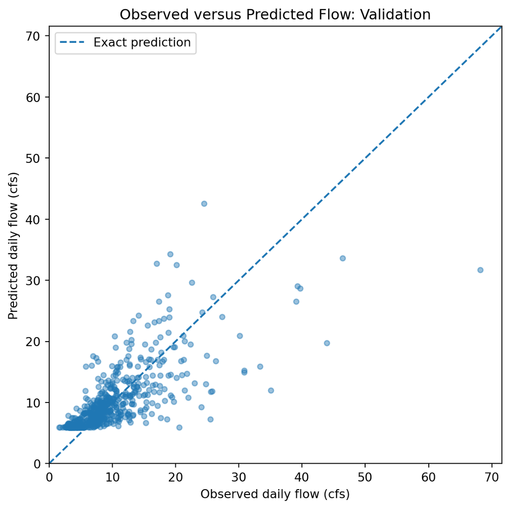

Figure 5: Three-window rainfall OLS on the validation sample. The dashed line represents exact predictions.

```python
observed_flow = (
    regression_validation[
        "FLOW_CFS"
    ]
)

predicted_flow = (
    regression_validation[
        "PRED_MULTIPLE_OLS_CFS"
    ]
)

plot_lower = min(
    0,
    observed_flow.min(),
    predicted_flow.min()
)

plot_upper = max(
    observed_flow.max(),
    predicted_flow.max()
) * 1.05

plt.figure(
    figsize=(
        6,
        6
    )
)

plt.scatter(
    observed_flow,
    predicted_flow,
    s=18,
    alpha=0.45
)

plt.plot(
    [
        plot_lower,
        plot_upper
    ],
    [
        plot_lower,
        plot_upper
    ],
    "--",
    label="Exact prediction"
)

plt.xlim(
    plot_lower,
    plot_upper
)

plt.ylim(
    plot_lower,
    plot_upper
)

plt.title(
    "Observed versus Predicted Flow: Validation"
)

plt.xlabel(
    "Observed daily flow (cfs)"
)

plt.ylabel(
    "Predicted daily flow (cfs)"
)

plt.legend()

plt.tight_layout()

plt.show()
```

### 12.11 Training Residuals versus Fitted Values

Residuals are observed minus fitted flow.

```python
training_diagnostics = (
    train[
        [
            "DATE",
            "FLOW_CFS"
        ]
    ].copy()
)

training_diagnostics[
    "FITTED_CFS"
] = multiple_fit.fittedvalues

training_diagnostics[
    "RESIDUAL_CFS"
] = (
    training_diagnostics[
        "FLOW_CFS"
    ]
    - training_diagnostics[
        "FITTED_CFS"
    ]
)

print(
    "Mean training residual (cfs):",
    round(
        training_diagnostics[
            "RESIDUAL_CFS"
        ].mean(),
        6
    )
)
```

```
Mean training residual (cfs): 0.0
```

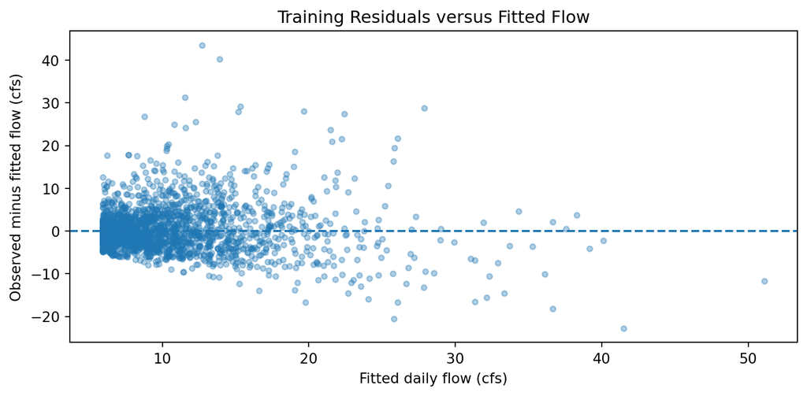

Figure 6: Training residuals from the three-window rainfall OLS model.

```python
plt.figure(
    figsize=(
        8,
        4
    )
)

plt.scatter(
    training_diagnostics[
        "FITTED_CFS"
    ],
    training_diagnostics[
        "RESIDUAL_CFS"
    ],
    s=14,
    alpha=0.35
)

plt.axhline(
    0,
    linestyle="--"
)

plt.title(
    "Training Residuals versus Fitted Flow"
)

plt.xlabel(
    "Fitted daily flow (cfs)"
)

plt.ylabel(
    "Observed minus fitted flow (cfs)"
)

plt.tight_layout()

plt.show()
```

### 12.12 Calendar-Day Residual Correlations

```python
training_calendar = pd.date_range(
    "2015-01-01",
    "2021-12-31",
    freq="D"
)

residual_calendar = (
    training_diagnostics.set_index(
        "DATE"
    )
)

residual_calendar = (
    residual_calendar.reindex(
        training_calendar
    )
)

current_residual = (
    residual_calendar[
        "RESIDUAL_CFS"
    ]
)

residual_lags = pd.DataFrame(
    index=[
        1,
        3,
        7
    ]
)

residual_lags.index.name = (
    "Calendar lag (days)"
)

for lag in [
    1,
    3,
    7
]:

    earlier_residual = (
        current_residual.shift(
            lag
        )
    )

    available_pairs = (
        current_residual.notna()
        & earlier_residual.notna()
    )

    current_values = (
        current_residual.loc[
            available_pairs
        ]
    )

    earlier_values = (
        earlier_residual.loc[
            available_pairs
        ]
    )

    residual_lags.loc[
        lag,
        "Available pairs"
    ] = available_pairs.sum()

    residual_lags.loc[
        lag,
        "Correlation"
    ] = current_values.corr(
        earlier_values
    )

residual_lags[
    "Available pairs"
] = residual_lags[
    "Available pairs"
].astype(
    int
)

residual_lags.round(
    3
)
```

| Calendar lag (days) | Available pairs | Correlation |
| --- | --- | --- |
| 1 | 2543 | 0.452 |
| 3 | 2539 | 0.400 |
| 7 | 2535 | 0.341 |

These correlations are descriptive diagnostics, not significance tests or proof of independent errors.[^20]

### 12.13 Save the Regression Results

```python
results_dir = Path(
    "Results/Tables"
)

results_dir.mkdir(
    parents=True,
    exist_ok=True
)

multiple_coefficients.to_csv(
    results_dir
    / "12_multiple_ols_coefficients.csv",
    index_label="Term"
)

validation_comparison.to_csv(
    results_dir
    / "12_validation_model_comparison.csv",
    index_label="Model"
)

regression_validation.to_csv(
    results_dir
    / "12_validation_predictions.csv",
    index=False,
    date_format="%Y-%m-%d"
)

print(
    "Saved regression results in:",
    results_dir
)
```

```
Saved regression results in: Results/Tables
```

### 12.14 Findings and Interpretation

Training R-squared rises from about 0.335 for the one-day model to about 0.481 for the three-window model.

The three-window model also improves validation MAE and RMSE relative to the one-day rainfall model and both mean baselines.

Three-window OLS validation MAE is approximately 2.865 cfs.

Persistence has lower MAE at approximately 2.557 cfs, while three-window OLS has lower RMSE than persistence.

The one-day training residual correlation is approximately 0.452, indicating noticeable remaining temporal dependence.

## Part 13 — Regularization and Tree-Based Model Comparison

### 13.1 Purpose and Comparison Rules

We add three rainfall-only candidates:

- ridge regression;
- regression tree;
- random forest.

All use the same three rainfall-history predictors, training dates, and validation dates as the multiple OLS model.

| Candidate | Fixed settings |
| --- | --- |
| Ridge | Standardized rainfall features; alpha = 10 |
| Regression tree | Maximum depth = 4; minimum leaf size = 20 |
| Random forest | 300 trees; maximum depth = 6; minimum leaf size = 10; two candidate features per split |

These configurations are fixed comparison choices, not an exhaustive hyperparameter search.

### 13.2 Prepare Model Inputs

```python
import sklearn

from sklearn.linear_model import Ridge

from sklearn.tree import (
    DecisionTreeRegressor,
    export_text
)

from sklearn.ensemble import (
    RandomForestRegressor
)

X_train_ml = (
    train[
        rain_predictors
    ].copy()
)

X_validation_ml = (
    validation[
        rain_predictors
    ].copy()
)

y_train_ml = (
    train[
        "FLOW_CFS"
    ].copy()
)

y_validation_ml = (
    validation[
        "FLOW_CFS"
    ].copy()
)

if not regression_validation[
    "DATE"
].equals(
    validation[
        "DATE"
    ]
):

    raise ValueError(
        "Keep the same validation dates for every model."
    )

print(
    "scikit-learn version:",
    sklearn.__version__
)

print(
    "Training rows:",
    len(
        X_train_ml
    )
)

print(
    "Validation rows:",
    len(
        X_validation_ml
    )
)
```

```
scikit-learn version: 1.3.0
Training rows: 2545
Validation rows: 653
```

### 13.3 Standardize Rainfall Features for Ridge

Training means and standard deviations are reused for validation.[^21]

```python
rain_training_means = (
    X_train_ml.mean()
)

rain_training_scales = (
    X_train_ml.std(
        ddof=0
    )
)

if (
    rain_training_scales
    == 0
).any():

    raise ValueError(
        "Review a rainfall predictor with no training variation."
    )

X_train_scaled = (
    X_train_ml
    - rain_training_means
) / rain_training_scales

X_validation_scaled = (
    X_validation_ml
    - rain_training_means
) / rain_training_scales

scaling_table = pd.DataFrame(
    index=rain_predictors
)

scaling_table[
    "Training mean (mm)"
] = rain_training_means

scaling_table[
    "Training standard deviation (mm)"
] = rain_training_scales

scaling_table.round(
    3
)
```

|  | Training mean (mm) | Training standard deviation (mm) |
| --- | --- | --- |
| RAIN_PREV_1D_MM | 2.802 | 6.055 |
| RAIN_PREV_3D_MM | 8.412 | 12.806 |
| RAIN_PREV_7D_MM | 19.632 | 22.654 |

### 13.4 Fit Ridge Regression

Ridge regression adds a squared-coefficient penalty to the least-squares objective.[^22]

```python
ridge_model = Ridge(
    alpha=10.0,
    fit_intercept=True,
    solver="svd"
)

ridge_model.fit(
    X_train_scaled,
    y_train_ml
)

ml_validation = (
    regression_validation.copy()
)

ml_validation[
    "PRED_RIDGE_CFS"
] = ridge_model.predict(
    X_validation_scaled
)
```

### 13.5 Compare Ridge and OLS Coefficients in Original Units

```python
ridge_original_slopes = pd.Series(
    ridge_model.coef_,
    index=rain_predictors
)

ridge_original_slopes = (
    ridge_original_slopes
    / rain_training_scales
)

ridge_original_intercept = (
    ridge_model.intercept_
    - (
        ridge_original_slopes
        * rain_training_means
    ).sum()
)

slope_comparison = pd.DataFrame(
    index=rain_predictors
)

slope_comparison[
    "OLS: cfs per mm"
] = multiple_fit.params.loc[
    rain_predictors
]

slope_comparison[
    "Ridge: cfs per mm"
] = ridge_original_slopes

print(
    "Ridge intercept in original units (cfs):",
    round(
        ridge_original_intercept,
        4
    )
)

slope_comparison.round(
    4
)
```

```
Ridge intercept in original units (cfs): 5.9469
```

|  | OLS: cfs per mm | Ridge: cfs per mm |
| --- | --- | --- |
| RAIN_PREV_1D_MM | 0.3802 | 0.3778 |
| RAIN_PREV_3D_MM | 0.0441 | 0.0460 |
| RAIN_PREV_7D_MM | 0.1221 | 0.1211 |

### 13.6 Fit a Regression Tree

The regression tree recursively partitions the rainfall-feature space and predicts using training responses within terminal leaves.[^23]

```python
tree_model = DecisionTreeRegressor(
    criterion="squared_error",
    max_depth=4,
    min_samples_leaf=20,
    random_state=42
)

tree_model.fit(
    X_train_ml,
    y_train_ml
)

ml_validation[
    "PRED_TREE_CFS"
] = tree_model.predict(
    X_validation_ml
)

print(
    "Fitted tree depth:",
    tree_model.get_depth()
)

print(
    "Number of leaves:",
    tree_model.get_n_leaves()
)
```

```
Fitted tree depth: 4
Number of leaves: 16
```

### 13.7 Inspect the Upper Tree Rules

The printed thresholds are statistical splits, not flood thresholds.

`export_text` is used only to display a readable subset of the fitted tree rules; it does not modify the fitted estimator.[^24]

```python
tree_rules = export_text(
    tree_model,
    feature_names=rain_predictors,
    max_depth=2,
    decimals=2
)

print(
    tree_rules
)
```

```
|--- RAIN_PREV_3D_MM <= 6.65
|   |--- RAIN_PREV_7D_MM <= 7.65
|   |   |--- RAIN_PREV_1D_MM <= 0.15
|   |   |   |--- truncated branch of depth 2
|   |   |--- RAIN_PREV_1D_MM >  0.15
|   |   |   |--- truncated branch of depth 2
|   |--- RAIN_PREV_7D_MM >  7.65
|   |   |--- RAIN_PREV_1D_MM <= 0.15
|   |   |   |--- truncated branch of depth 2
|   |   |--- RAIN_PREV_1D_MM >  0.15
|   |   |   |--- truncated branch of depth 2
|--- RAIN_PREV_3D_MM >  6.65
|   |--- RAIN_PREV_7D_MM <= 36.35
|   |   |--- RAIN_PREV_1D_MM <= 3.70
|   |   |   |--- truncated branch of depth 2
|   |   |--- RAIN_PREV_1D_MM >  3.70
|   |   |   |--- truncated branch of depth 2
|   |--- RAIN_PREV_7D_MM >  36.35
|   |   |--- RAIN_PREV_1D_MM <= 15.75
|   |   |   |--- truncated branch of depth 2
|   |   |--- RAIN_PREV_1D_MM >  15.75
|   |   |   |--- truncated branch of depth 2
```

### 13.8 Fit a Random Forest

The random forest averages predictions across regression trees fitted to bootstrap samples of the training data.[^25]

```python
forest_model = RandomForestRegressor(
    n_estimators=300,
    criterion="squared_error",
    max_depth=6,
    min_samples_leaf=10,
    max_features=2,
    bootstrap=True,
    oob_score=False,
    random_state=42,
    n_jobs=1
)

forest_model.fit(
    X_train_ml,
    y_train_ml
)

ml_validation[
    "PRED_FOREST_CFS"
] = forest_model.predict(
    X_validation_ml
)
```

### 13.9 Compare All Validation Scores

```python
ml_columns = {
    "Ridge rainfall":
        "PRED_RIDGE_CFS",

    "Regression tree rainfall":
        "PRED_TREE_CFS",

    "Random forest rainfall":
        "PRED_FOREST_CFS"
}

all_validation_results = (
    validation_comparison.copy()
)

for model_name in ml_columns:

    prediction_column = (
        ml_columns[
            model_name
        ]
    )

    predicted = (
        ml_validation[
            prediction_column
        ]
    )

    if predicted.isna().any():

        raise ValueError(
            "A candidate prediction is missing."
        )

    errors = (
        y_validation_ml
        - predicted
    )

    all_validation_results.loc[
        model_name,
        "Validation days"
    ] = len(
        y_validation_ml
    )

    all_validation_results.loc[
        model_name,
        "MAE_cfs"
    ] = errors.abs().mean()

    all_validation_results.loc[
        model_name,
        "RMSE_cfs"
    ] = (
        (
            errors ** 2
        ).mean()
        ** 0.5
    )

all_validation_results[
    "Validation days"
] = (
    all_validation_results[
        "Validation days"
    ].astype(
        int
    )
)

all_validation_results.round(
    3
)
```

|  | Validation days | MAE_cfs | RMSE_cfs |
| --- | --- | --- | --- |
| Training mean | 653 | 4.603 | 6.538 |
| Calendar-month mean | 653 | 3.673 | 5.635 |
| Previous-day flow | 653 | 2.557 | 5.243 |
| One-day rainfall OLS | 653 | 3.523 | 4.912 |
| Three-window rainfall OLS | 653 | 2.865 | 4.384 |
| Ridge rainfall | 653 | 2.866 | 4.382 |
| Regression tree rainfall | 653 | 2.719 | 4.251 |
| Random forest rainfall | 653 | 2.649 | 4.151 |

### 13.10 Compare Training and Validation Error

```python
training_predictions = pd.DataFrame(
    index=train.index
)

training_predictions[
    "Three-window rainfall OLS"
] = multiple_fit.fittedvalues

training_predictions[
    "Ridge rainfall"
] = ridge_model.predict(
    X_train_scaled
)

training_predictions[
    "Regression tree rainfall"
] = tree_model.predict(
    X_train_ml
)

training_predictions[
    "Random forest rainfall"
] = forest_model.predict(
    X_train_ml
)

fit_comparison = pd.DataFrame(
    index=training_predictions.columns
)

for model_name in training_predictions.columns:

    training_errors = (
        y_train_ml
        - training_predictions[
            model_name
        ]
    )

    fit_comparison.loc[
        model_name,
        "Training MAE"
    ] = training_errors.abs().mean()

    fit_comparison.loc[
        model_name,
        "Training RMSE"
    ] = (
        (
            training_errors ** 2
        ).mean()
        ** 0.5
    )

    fit_comparison.loc[
        model_name,
        "Validation MAE"
    ] = all_validation_results.loc[
        model_name,
        "MAE_cfs"
    ]

    fit_comparison.loc[
        model_name,
        "Validation RMSE"
    ] = all_validation_results.loc[
        model_name,
        "RMSE_cfs"
    ]

fit_comparison.round(
    3
)
```

|  | Training MAE | Training RMSE | Validation MAE | Validation RMSE |
| --- | --- | --- | --- | --- |
| Three-window rainfall OLS | 3.426 | 5.057 | 2.865 | 4.384 |
| Ridge rainfall | 3.427 | 5.057 | 2.866 | 4.382 |
| Regression tree rainfall | 3.258 | 4.855 | 2.719 | 4.251 |
| Random forest rainfall | 3.075 | 4.569 | 2.649 | 4.151 |

### 13.11 Visualize Validation MAE

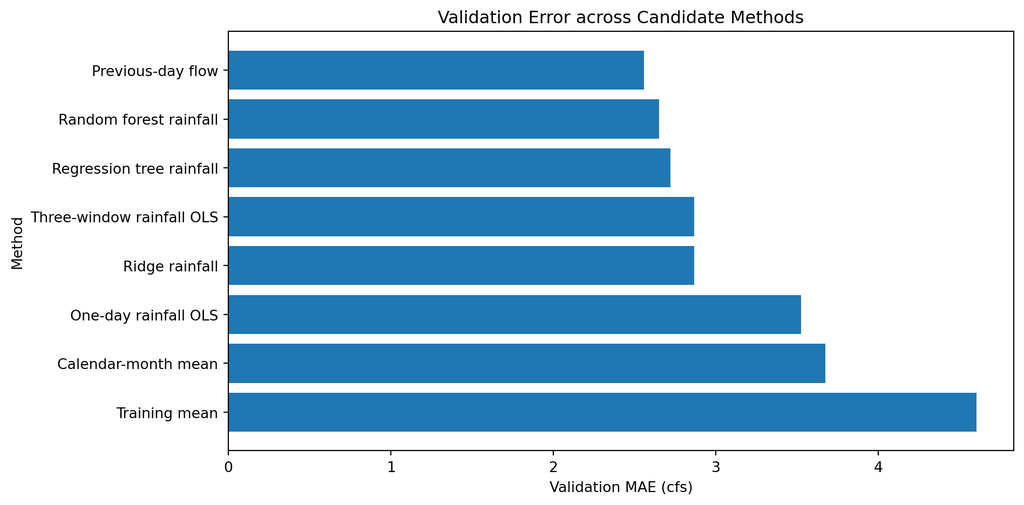

Figure 7: Validation MAE for the fixed candidate models and baselines.

```python
mae_plot = (
    all_validation_results.sort_values(
        "MAE_cfs",
        ascending=False
    )
)

plt.figure(
    figsize=(
        10,
        5
    )
)

plt.barh(
    mae_plot.index,
    mae_plot[
        "MAE_cfs"
    ]
)

plt.xlabel(
    "Validation MAE (cfs)"
)

plt.ylabel(
    "Method"
)

plt.title(
    "Validation Error across Candidate Methods"
)

plt.xlim(
    left=0
)

plt.tight_layout()

plt.show()
```

### 13.12 Validation Interpretation

The fixed random-forest configuration has the lowest validation MAE and RMSE among the rainfall-only models.

Persistence nevertheless has the lowest overall validation MAE.

The random forest has the lowest validation RMSE.

Therefore no single method dominates under both validation metrics.

Overall MAE and RMSE do not establish flood-event prediction performance.

### 13.13 Save Results and Configuration

```python
ml_results_dir = Path(
    "Results/Tables"
)

ml_results_dir.mkdir(
    parents=True,
    exist_ok=True
)

all_validation_results.to_csv(
    ml_results_dir
    / "13_validation_model_comparison.csv",
    index_label="Model"
)

fit_comparison.to_csv(
    ml_results_dir
    / "13_training_validation_errors.csv",
    index_label="Model"
)

ml_validation.to_csv(
    ml_results_dir
    / "13_validation_predictions.csv",
    index=False,
    date_format="%Y-%m-%d"
)

scaling_table.to_csv(
    ml_results_dir
    / "13_ridge_scaling.csv",
    index_label="Predictor"
)

model_settings = pd.DataFrame(
    index=list(
        ml_columns
    )
)

model_settings[
    "Settings"
] = [
    str(
        ridge_model.get_params()
    ),
    str(
        tree_model.get_params()
    ),
    str(
        forest_model.get_params()
    )
]

model_settings[
    "scikit-learn version"
] = sklearn.__version__

model_settings.to_csv(
    ml_results_dir
    / "13_model_settings.csv",
    index_label="Model"
)

print(
    "Saved Part 13 results in:",
    ml_results_dir
)
```

```
Saved Part 13 results in: Results/Tables
```

**Robustness and Final Evaluation**

## Part 14 — Robustness and Higher-Flow Performance

### 14.1 Purpose

The validation comparison summarizes average prediction error across all retained validation dates.

It does not show whether the conclusions depend strongly on provisional flow records or whether model errors are different during unusually high-flow conditions.

Therefore, perform two additional checks:

1. evaluate the fitted models on validation dates whose target and previous-day flow values are both unflagged;
2. evaluate performance when observed flow exceeds a threshold defined from the training period only.

No model is refitted or tuned in this section.

### 14.2 Define the Common Prediction Columns

```python
robustness_prediction_columns = {
    "Training mean":
        "PRED_MEAN_CFS",

    "Calendar-month mean":
        "PRED_MONTH_MEAN_CFS",

    "Previous-day flow":
        "PRED_PERSISTENCE_CFS",

    "One-day rainfall OLS":
        "PRED_SIMPLE_OLS_CFS",

    "Three-window rainfall OLS":
        "PRED_MULTIPLE_OLS_CFS",

    "Ridge rainfall":
        "PRED_RIDGE_CFS",

    "Regression tree rainfall":
        "PRED_TREE_CFS",

    "Random forest rainfall":
        "PRED_FOREST_CFS"
}

for robustness_column in (
    robustness_prediction_columns.values()
):

    if robustness_column not in (
        ml_validation.columns
    ):

        raise ValueError(
            "Missing validation prediction column: "
            + robustness_column
        )
```

### 14.3 Quality-Status Sensitivity Sample

The main experiment retains provisional site-58A observations.

For this sensitivity check, a validation date is retained only when:

- the target flow is not marked provisional;
- previous-day flow is not marked provisional.

This does not mean provisional observations are wrong.

It only asks whether the main validation pattern changes on a more restricted subset.

```python
validation_target_unflagged = (
    ml_validation[
        "PROVISIONAL_FLAG"
    ]
    .eq(
        False
    )
    .fillna(
        False
    )
)

validation_previous_unflagged = (
    ml_validation[
        "FLOW_PREV_1D_PROVISIONAL"
    ]
    .eq(
        False
    )
    .fillna(
        False
    )
)

validation_quality_mask = (
    validation_target_unflagged
    & validation_previous_unflagged
)

validation_quality_subset = (
    ml_validation.loc[
        validation_quality_mask
    ].copy()
)

print(
    "Full validation rows:",
    len(
        ml_validation
    )
)

print(
    "Quality-sensitivity rows:",
    len(
        validation_quality_subset
    )
)
```

```
Full validation rows: 653
Quality-sensitivity rows: 236
```

### 14.4 Score the Quality-Sensitivity Sample

```python
quality_sensitivity_results = pd.DataFrame(
    index=list(
        robustness_prediction_columns
    )
)

quality_sensitivity_results.index.name = (
    "Method"
)

quality_sensitivity_results[
    "Validation days"
] = len(
    validation_quality_subset
)

for method_name in (
    robustness_prediction_columns
):

    prediction_column = (
        robustness_prediction_columns[
            method_name
        ]
    )

    observed = (
        validation_quality_subset[
            "FLOW_CFS"
        ]
    )

    predicted = (
        validation_quality_subset[
            prediction_column
        ]
    )

    errors = (
        observed
        - predicted
    )

    quality_sensitivity_results.loc[
        method_name,
        "MAE_cfs"
    ] = errors.abs().mean()

    quality_sensitivity_results.loc[
        method_name,
        "RMSE_cfs"
    ] = (
        (
            errors ** 2
        ).mean()
        ** 0.5
    )

quality_sensitivity_results.round(
    3
)
```

| Method | Validation days | MAE_cfs | RMSE_cfs |
| --- | --- | --- | --- |
| Training mean | 236 | 4.460 | 5.513 |
| Calendar-month mean | 236 | 3.888 | 5.090 |
| Previous-day flow | 236 | 1.984 | 3.766 |
| One-day rainfall OLS | 236 | 3.344 | 4.298 |
| Three-window rainfall OLS | 236 | 2.309 | 3.286 |
| Ridge rainfall | 236 | 2.312 | 3.286 |
| Regression tree rainfall | 236 | 2.156 | 3.165 |
| Random forest rainfall | 236 | 2.097 | 3.043 |

The models are not refitted on this restricted sample.

Therefore this analysis checks evaluation sensitivity, not the influence of provisional training observations on fitted coefficients.

### 14.5 Define a Training-Based Higher-Flow Threshold

Higher flow is defined as the 90th percentile of training responses.

$$q_{0.90}
=
\operatorname{Quantile}_{0.90}
\left(
Q_t:
t\in\mathcal T_{\mathrm{train}}
\right).$$

The threshold is estimated only from the 2015–2021 training period.[^26]

It is a statistical threshold, not an official flood threshold.

```python
high_flow_threshold_cfs = (
    train[
        "FLOW_CFS"
    ].quantile(
        0.90
    )
)

print(
    "Training 90th-percentile flow threshold (cfs):",
    round(
        high_flow_threshold_cfs,
        3
    )
)
```

```
Training 90th-percentile flow threshold (cfs): 19.368
```

### 14.6 Create the Higher-Flow Validation Subset

```python
validation_high_flow_mask = (
    ml_validation[
        "FLOW_CFS"
    ]
    >= high_flow_threshold_cfs
)

validation_high_flow = (
    ml_validation.loc[
        validation_high_flow_mask
    ].copy()
)

print(
    "Higher-flow validation dates:",
    len(
        validation_high_flow
    )
)

print(
    "Minimum observed flow in subset:",
    round(
        validation_high_flow[
            "FLOW_CFS"
        ].min(),
        3
    )
)

print(
    "Maximum observed flow in subset:",
    round(
        validation_high_flow[
            "FLOW_CFS"
        ].max(),
        3
    )
)
```

```
Higher-flow validation dates: 40
Minimum observed flow in subset: 19.41
Maximum observed flow in subset: 68.15
```

### 14.7 Evaluate Higher-Flow Validation Performance

```python
high_flow_validation_results = pd.DataFrame(
    index=list(
        robustness_prediction_columns
    )
)

high_flow_validation_results.index.name = (
    "Method"
)

high_flow_validation_results[
    "Higher-flow days"
] = len(
    validation_high_flow
)

for method_name in (
    robustness_prediction_columns
):

    prediction_column = (
        robustness_prediction_columns[
            method_name
        ]
    )

    observed = (
        validation_high_flow[
            "FLOW_CFS"
        ]
    )

    predicted = (
        validation_high_flow[
            prediction_column
        ]
    )

    errors = (
        observed
        - predicted
    )

    high_flow_validation_results.loc[
        method_name,
        "MAE_cfs"
    ] = errors.abs().mean()

    high_flow_validation_results.loc[
        method_name,
        "RMSE_cfs"
    ] = (
        (
            errors ** 2
        ).mean()
        ** 0.5
    )

high_flow_validation_results.round(
    3
)
```

| Method | Higher-flow days | MAE_cfs | RMSE_cfs |
| --- | --- | --- | --- |
| Training mean | 40 | 17.589 | 20.018 |
| Calendar-month mean | 40 | 13.843 | 16.749 |
| Previous-day flow | 40 | 13.820 | 17.027 |
| One-day rainfall OLS | 40 | 11.456 | 13.386 |
| Three-window rainfall OLS | 40 | 10.439 | 12.749 |
| Ridge rainfall | 40 | 10.448 | 12.755 |
| Regression tree rainfall | 40 | 9.946 | 12.414 |
| Random forest rainfall | 40 | 9.892 | 12.208 |

### 14.8 Compare Overall and Higher-Flow MAE

```python
validation_robustness_comparison = pd.DataFrame(
    index=list(
        robustness_prediction_columns
    )
)

validation_robustness_comparison.index.name = (
    "Method"
)

validation_robustness_comparison[
    "Overall_MAE_cfs"
] = all_validation_results[
    "MAE_cfs"
]

validation_robustness_comparison[
    "Quality_subset_MAE_cfs"
] = quality_sensitivity_results[
    "MAE_cfs"
]

validation_robustness_comparison[
    "Higher_flow_MAE_cfs"
] = high_flow_validation_results[
    "MAE_cfs"
]

validation_robustness_comparison.round(
    3
)
```

| Method | Overall_MAE_cfs | Quality_subset_MAE_cfs | Higher_flow_MAE_cfs |
| --- | --- | --- | --- |
| Training mean | 4.603 | 4.460 | 17.589 |
| Calendar-month mean | 3.673 | 3.888 | 13.843 |
| Previous-day flow | 2.557 | 1.984 | 13.820 |
| One-day rainfall OLS | 3.523 | 3.344 | 11.456 |
| Three-window rainfall OLS | 2.865 | 2.309 | 10.439 |
| Ridge rainfall | 2.866 | 2.312 | 10.448 |
| Regression tree rainfall | 2.719 | 2.156 | 9.946 |
| Random forest rainfall | 2.649 | 2.097 | 9.892 |

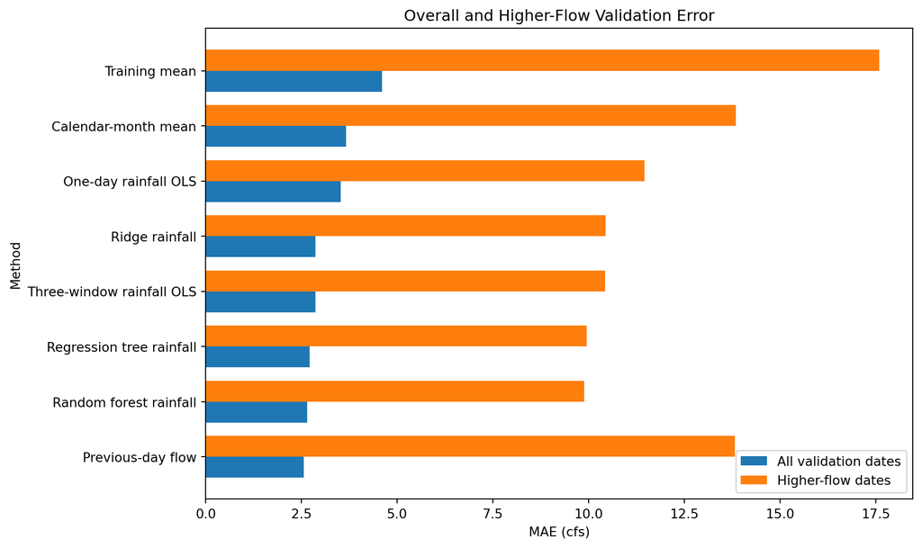

Figure 8: Validation MAE on all retained dates and on dates above the training-period 90th-percentile flow threshold.

```python
high_flow_plot = (
    validation_robustness_comparison[
        [
            "Overall_MAE_cfs",
            "Higher_flow_MAE_cfs"
        ]
    ].copy()
)

high_flow_plot = (
    high_flow_plot.sort_values(
        "Overall_MAE_cfs",
        ascending=True
    )
)

plot_positions = list(
    range(
        len(
            high_flow_plot
        )
    )
)

bar_width = 0.38

plt.figure(
    figsize=(
        10,
        6
    )
)

plt.barh(
    [
        position
        - bar_width / 2
        for position in (
            plot_positions
        )
    ],
    high_flow_plot[
        "Overall_MAE_cfs"
    ],
    height=bar_width,
    label="All validation dates"
)

plt.barh(
    [
        position
        + bar_width / 2
        for position in (
            plot_positions
        )
    ],
    high_flow_plot[
        "Higher_flow_MAE_cfs"
    ],
    height=bar_width,
    label="Higher-flow dates"
)

plt.yticks(
    plot_positions,
    high_flow_plot.index
)

plt.xlabel(
    "MAE (cfs)"
)

plt.ylabel(
    "Method"
)

plt.title(
    "Overall and Higher-Flow Validation Error"
)

plt.legend()

plt.tight_layout()

plt.show()
```

### 14.9 Robustness Findings

The quality-status sensitivity sample contains 236 validation dates.

Approximate MAE on this restricted sample is:

| Method | MAE (cfs) |
| --- | --- |
| Previous-day flow | 1.984 |
| Random forest rainfall | 2.097 |
| Regression tree rainfall | 2.156 |
| Three-window rainfall OLS | 2.309 |
| Ridge rainfall | 2.312 |

The main validation pattern therefore remains broadly similar after the quality-status restriction.

The training-period 90th-percentile flow threshold is approximately:

$$19.368\ \text{cfs}.$$

Forty validation dates meet or exceed this threshold.

Approximate higher-flow MAE is:

| Method | Higher-flow MAE (cfs) |
| --- | --- |
| Random forest rainfall | 9.892 |
| Regression tree rainfall | 9.946 |
| Three-window rainfall OLS | 10.439 |
| Ridge rainfall | 10.448 |
| One-day rainfall OLS | 11.456 |
| Previous-day flow | 13.820 |

Persistence has the lowest overall validation MAE but does not have the lowest MAE on the higher-flow subset.

This does not establish flood-warning performance because the subset uses daily mean discharge and contains only 40 dates.

### 14.10 Save Robustness Results

```python
robustness_results_dir = Path(
    "Results/Tables"
)

robustness_results_dir.mkdir(
    parents=True,
    exist_ok=True
)

quality_sensitivity_results.to_csv(
    robustness_results_dir
    / "14_quality_sensitivity_validation.csv",
    index_label="Method"
)

high_flow_validation_results.to_csv(
    robustness_results_dir
    / "14_high_flow_validation.csv",
    index_label="Method"
)

validation_robustness_comparison.to_csv(
    robustness_results_dir
    / "14_validation_robustness_comparison.csv",
    index_label="Method"
)

high_flow_settings = pd.DataFrame(
    {
        "Setting": [
            "Training flow quantile",
            "Higher-flow threshold (cfs)",
            "Validation higher-flow days",
            "Quality-sensitivity validation days"
        ],

        "Value": [
            0.90,
            high_flow_threshold_cfs,
            len(
                validation_high_flow
            ),
            len(
                validation_quality_subset
            )
        ]
    }
)

high_flow_settings.to_csv(
    robustness_results_dir
    / "14_robustness_settings.csv",
    index=False
)

print(
    "Saved Part 14 results in:",
    robustness_results_dir
)
```

```
Saved Part 14 results in: Results/Tables
```

## Part 15 — Final Test Evaluation

### 15.1 Freeze the Evaluation Policy

The reserved test period covers January 1, 2024 through December 31, 2025.

The following choices remain fixed before test scoring:

- rainfall predictors;
- chronological period boundaries;
- baseline definitions;
- OLS specifications;
- ridge penalty;
- tree and forest settings;
- MAE and RMSE definitions;
- higher-flow threshold;
- treatment of provisional records.

The estimators remain those fitted using 2015–2021 training observations.

Validation data are not added to the fitting sample before the final test.

This conservative choice avoids introducing a new refitting rule after validation results have already been inspected.[^27]

### 15.2 Prepare the Test Table

```python
test_predictions = (
    test.copy()
)

if len(
    test_predictions
) == 0:

    raise ValueError(
        "The reserved test sample is empty."
    )

print(
    "Test rows:",
    len(
        test_predictions
    )
)

print(
    "First test date:",
    test_predictions[
        "DATE"
    ].min()
)

print(
    "Last test date:",
    test_predictions[
        "DATE"
    ].max()
)
```

```
Test rows: 723
First test date: 2024-01-01 00:00:00
Last test date: 2025-12-31 00:00:00
```

### 15.3 Apply the Three Baselines

```python
test_predictions[
    "PRED_MEAN_CFS"
] = training_mean

test_predictions[
    "PRED_MONTH_MEAN_CFS"
] = test_predictions[
    "MONTH"
].map(
    training_month_means
)

test_predictions[
    "PRED_PERSISTENCE_CFS"
] = test_predictions[
    "FLOW_PREV_1D_CFS"
]

if test_predictions[
    [
        "PRED_MEAN_CFS",
        "PRED_MONTH_MEAN_CFS",
        "PRED_PERSISTENCE_CFS"
    ]
].isna().any().any():

    raise ValueError(
        "A test baseline prediction is missing."
    )
```

### 15.4 Apply the OLS Models

```python
X_test = (
    test[
        rain_predictors
    ].copy()
)

X_test_simple = (
    X_test[
        [
            "RAIN_PREV_1D_MM"
        ]
    ].copy()
)

X_test_simple = sm.add_constant(
    X_test_simple,
    has_constant="add"
)

X_test_multiple = sm.add_constant(
    X_test,
    has_constant="add"
)

test_predictions[
    "PRED_SIMPLE_OLS_CFS"
] = simple_fit.predict(
    X_test_simple
)

test_predictions[
    "PRED_MULTIPLE_OLS_CFS"
] = multiple_fit.predict(
    X_test_multiple
)
```

### 15.5 Apply Ridge, Tree, and Random Forest

Ridge uses the training-period scaling quantities from Part 13.

```python
X_test_scaled = (
    X_test
    - rain_training_means
) / rain_training_scales

test_predictions[
    "PRED_RIDGE_CFS"
] = ridge_model.predict(
    X_test_scaled
)

test_predictions[
    "PRED_TREE_CFS"
] = tree_model.predict(
    X_test
)

test_predictions[
    "PRED_FOREST_CFS"
] = forest_model.predict(
    X_test
)

test_model_columns = list(
    robustness_prediction_columns.values()
)

if test_predictions[
    test_model_columns
].isna().any().any():

    raise ValueError(
        "A final test prediction is missing."
    )
```

### 15.6 Calculate Final Test MAE and RMSE

All methods are scored on the same 723 test dates.

```python
final_test_results = pd.DataFrame(
    index=list(
        robustness_prediction_columns
    )
)

final_test_results.index.name = (
    "Method"
)

final_test_results[
    "Test days"
] = len(
    test_predictions
)

for method_name in (
    robustness_prediction_columns
):

    prediction_column = (
        robustness_prediction_columns[
            method_name
        ]
    )

    observed = (
        test_predictions[
            "FLOW_CFS"
        ]
    )

    predicted = (
        test_predictions[
            prediction_column
        ]
    )

    errors = (
        observed
        - predicted
    )

    final_test_results.loc[
        method_name,
        "MAE_cfs"
    ] = errors.abs().mean()

    final_test_results.loc[
        method_name,
        "RMSE_cfs"
    ] = (
        (
            errors ** 2
        ).mean()
        ** 0.5
    )

final_test_results.round(
    3
)
```

| Method | Test days | MAE_cfs | RMSE_cfs |
| --- | --- | --- | --- |
| Training mean | 723 | 4.430 | 5.247 |
| Calendar-month mean | 723 | 3.650 | 4.718 |
| Previous-day flow | 723 | 1.640 | 3.230 |
| One-day rainfall OLS | 723 | 3.603 | 4.384 |
| Three-window rainfall OLS | 723 | 3.239 | 4.059 |
| Ridge rainfall | 723 | 3.240 | 4.058 |
| Regression tree rainfall | 723 | 3.325 | 4.418 |
| Random forest rainfall | 723 | 3.249 | 4.274 |

### 15.7 Compare Validation and Test Performance

```python
validation_test_comparison = pd.DataFrame(
    index=list(
        robustness_prediction_columns
    )
)

validation_test_comparison.index.name = (
    "Method"
)

validation_test_comparison[
    "Validation_MAE_cfs"
] = all_validation_results[
    "MAE_cfs"
]

validation_test_comparison[
    "Test_MAE_cfs"
] = final_test_results[
    "MAE_cfs"
]

validation_test_comparison[
    "Validation_RMSE_cfs"
] = all_validation_results[
    "RMSE_cfs"
]

validation_test_comparison[
    "Test_RMSE_cfs"
] = final_test_results[
    "RMSE_cfs"
]

validation_test_comparison.round(
    3
)
```

| Method | Validation_MAE_cfs | Test_MAE_cfs | Validation_RMSE_cfs | Test_RMSE_cfs |
| --- | --- | --- | --- | --- |
| Training mean | 4.603 | 4.430 | 6.538 | 5.247 |
| Calendar-month mean | 3.673 | 3.650 | 5.635 | 4.718 |
| Previous-day flow | 2.557 | 1.640 | 5.243 | 3.230 |
| One-day rainfall OLS | 3.523 | 3.603 | 4.912 | 4.384 |
| Three-window rainfall OLS | 2.865 | 3.239 | 4.384 | 4.059 |
| Ridge rainfall | 2.866 | 3.240 | 4.382 | 4.058 |
| Regression tree rainfall | 2.719 | 3.325 | 4.251 | 4.418 |
| Random forest rainfall | 2.649 | 3.249 | 4.151 | 4.274 |

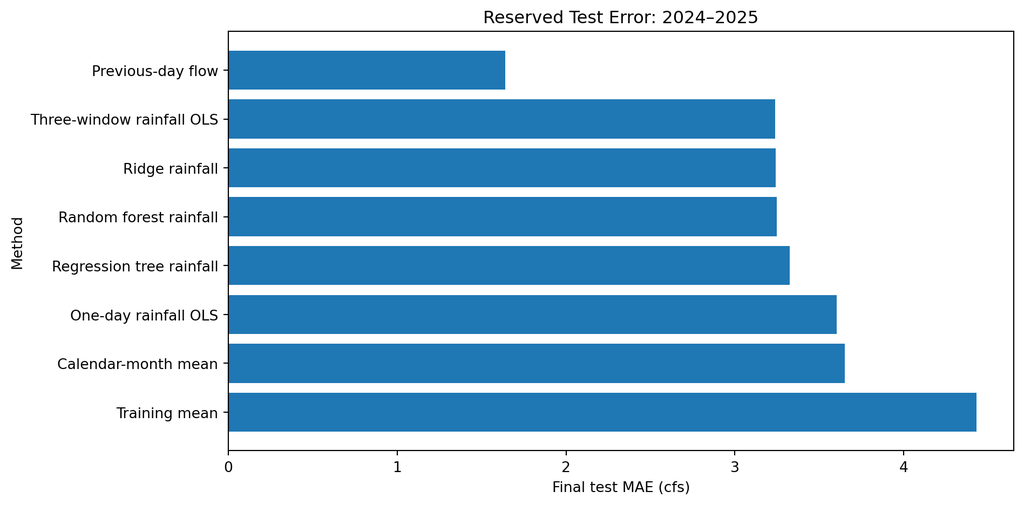

Figure 9: Final MAE on the reserved 2024–2025 test sample.

```python
final_mae_plot = (
    final_test_results.sort_values(
        "MAE_cfs",
        ascending=False
    )
)

plt.figure(
    figsize=(
        10,
        5
    )
)

plt.barh(
    final_mae_plot.index,
    final_mae_plot[
        "MAE_cfs"
    ]
)

plt.xlabel(
    "Final test MAE (cfs)"
)

plt.ylabel(
    "Method"
)

plt.title(
    "Reserved Test Error: 2024–2025"
)

plt.xlim(
    left=0
)

plt.tight_layout()

plt.show()
```

The following figure compares MAE between the development-period validation sample and the reserved test sample. It is intended to show changes in generalization rather than to select a new model from the test results.

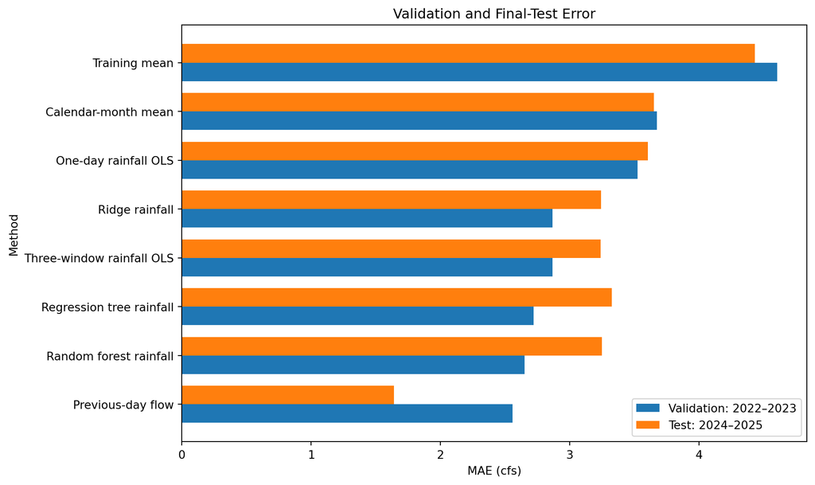

Figure 10: Validation and final-test MAE for all candidate methods. Test results are shown for final evaluation, not for additional model selection.

```python
validation_test_mae_plot = (
    validation_test_comparison[
        [
            "Validation_MAE_cfs",
            "Test_MAE_cfs"
        ]
    ].copy()
)

validation_test_mae_plot = (
    validation_test_mae_plot.sort_values(
        "Validation_MAE_cfs",
        ascending=True
    )
)

validation_test_positions = list(
    range(
        len(
            validation_test_mae_plot
        )
    )
)

validation_test_bar_width = 0.38

plt.figure(
    figsize=(
        10,
        6
    )
)

plt.barh(
    [
        position
        - validation_test_bar_width / 2
        for position in validation_test_positions
    ],
    validation_test_mae_plot[
        "Validation_MAE_cfs"
    ],
    height=validation_test_bar_width,
    label="Validation: 2022–2023"
)

plt.barh(
    [
        position
        + validation_test_bar_width / 2
        for position in validation_test_positions
    ],
    validation_test_mae_plot[
        "Test_MAE_cfs"
    ],
    height=validation_test_bar_width,
    label="Test: 2024–2025"
)

plt.yticks(
    validation_test_positions,
    validation_test_mae_plot.index
)

plt.xlabel(
    "MAE (cfs)"
)

plt.ylabel(
    "Method"
)

plt.title(
    "Validation and Final-Test Error"
)

plt.legend()

plt.tight_layout()

plt.show()
```

### 15.8 Visual Comparison on the Final Test Period

A time-series comparison helps show how the models behave across the full 2024–2025 test period, not just through summary error statistics.

The figure below compares:

- the observed daily mean flow;
- the previous-day-flow persistence benchmark;
- the three-window rainfall OLS model;
- the random forest rainfall model.

These three prediction series are shown because they represent:

- the strongest overall benchmark (persistence);
- the strongest simple rainfall model on the final test (three-window OLS);
- the strongest flexible rainfall model during validation (random forest).

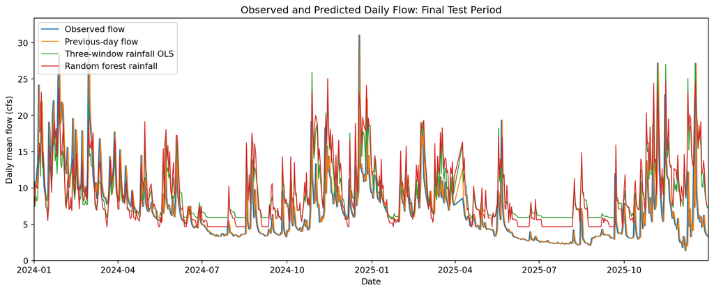

Figure 11: Observed daily flow and selected model predictions during the reserved 2024–2025 test period.

```python
plot_test = test_predictions[
    [
        "DATE",
        "FLOW_CFS",
        "PRED_PERSISTENCE_CFS",
        "PRED_MULTIPLE_OLS_CFS",
        "PRED_FOREST_CFS"
    ]
].copy()

plt.figure(
    figsize=(
        12,
        5
    )
)

plt.plot(
    plot_test[
        "DATE"
    ],
    plot_test[
        "FLOW_CFS"
    ],
    label="Observed flow",
    linewidth=1.4
)

plt.plot(
    plot_test[
        "DATE"
    ],
    plot_test[
        "PRED_PERSISTENCE_CFS"
    ],
    label="Previous-day flow",
    linewidth=1.0
)

plt.plot(
    plot_test[
        "DATE"
    ],
    plot_test[
        "PRED_MULTIPLE_OLS_CFS"
    ],
    label="Three-window rainfall OLS",
    linewidth=1.0
)

plt.plot(
    plot_test[
        "DATE"
    ],
    plot_test[
        "PRED_FOREST_CFS"
    ],
    label="Random forest rainfall",
    linewidth=1.0
)

plt.title(
    "Observed and Predicted Daily Flow: Final Test Period"
)

plt.xlabel(
    "Date"
)

plt.ylabel(
    "Daily mean flow (cfs)"
)

plt.xlim(
    pd.Timestamp("2024-01-01"),
    pd.Timestamp("2025-12-31")
)

plt.ylim(
    bottom=0
)

plt.legend()

plt.tight_layout()

plt.show()
```

The persistence series usually tracks short-run day-to-day movement closely, which is consistent with its low overall test error.

The rainfall-only models are less accurate overall, but their behavior near larger flow increases can still be visually compared with the persistence benchmark and the observed series.

This figure is descriptive. It complements MAE and RMSE, but it does not replace the numerical evaluation tables.

### 15.9 Higher-Flow Test Performance

The higher-flow threshold remains the training-period value from Part 14.

It is not recomputed from the test period.

```python
test_high_flow_mask = (
    test_predictions[
        "FLOW_CFS"
    ]
    >= high_flow_threshold_cfs
)

test_high_flow = (
    test_predictions.loc[
        test_high_flow_mask
    ].copy()
)

print(
    "Higher-flow test dates:",
    len(
        test_high_flow
    )
)

final_high_flow_results = pd.DataFrame(
    index=list(
        robustness_prediction_columns
    )
)

final_high_flow_results.index.name = (
    "Method"
)

final_high_flow_results[
    "Higher-flow test days"
] = len(
    test_high_flow
)

for method_name in (
    robustness_prediction_columns
):

    prediction_column = (
        robustness_prediction_columns[
            method_name
        ]
    )

    observed = (
        test_high_flow[
            "FLOW_CFS"
        ]
    )

    predicted = (
        test_high_flow[
            prediction_column
        ]
    )

    errors = (
        observed
        - predicted
    )

    final_high_flow_results.loc[
        method_name,
        "MAE_cfs"
    ] = errors.abs().mean()

    final_high_flow_results.loc[
        method_name,
        "RMSE_cfs"
    ] = (
        (
            errors ** 2
        ).mean()
        ** 0.5
    )

final_high_flow_results.round(
    3
)
```

```
Higher-flow test dates: 18
```

| Method | Higher-flow test days | MAE_cfs | RMSE_cfs |
| --- | --- | --- | --- |
| Training mean | 18 | 14.044 | 14.522 |
| Calendar-month mean | 18 | 8.526 | 9.577 |
| Previous-day flow | 18 | 8.933 | 11.269 |
| One-day rainfall OLS | 18 | 6.981 | 8.113 |
| Three-window rainfall OLS | 18 | 6.577 | 7.433 |
| Ridge rainfall | 18 | 6.596 | 7.444 |
| Regression tree rainfall | 18 | 5.994 | 6.851 |
| Random forest rainfall | 18 | 5.885 | 6.518 |

### 15.10 Final Quality-Sensitivity Check

```python
test_target_unflagged = (
    test_predictions[
        "PROVISIONAL_FLAG"
    ]
    .eq(
        False
    )
    .fillna(
        False
    )
)

test_previous_unflagged = (
    test_predictions[
        "FLOW_PREV_1D_PROVISIONAL"
    ]
    .eq(
        False
    )
    .fillna(
        False
    )
)

test_quality_mask = (
    test_target_unflagged
    & test_previous_unflagged
)

test_quality_subset = (
    test_predictions.loc[
        test_quality_mask
    ].copy()
)

print(
    "Quality-sensitivity test rows:",
    len(
        test_quality_subset
    )
)

final_quality_results = pd.DataFrame(
    index=list(
        robustness_prediction_columns
    )
)

final_quality_results.index.name = (
    "Method"
)

final_quality_results[
    "Test days"
] = len(
    test_quality_subset
)

for method_name in (
    robustness_prediction_columns
):

    prediction_column = (
        robustness_prediction_columns[
            method_name
        ]
    )

    observed = (
        test_quality_subset[
            "FLOW_CFS"
        ]
    )

    predicted = (
        test_quality_subset[
            prediction_column
        ]
    )

    errors = (
        observed
        - predicted
    )

    final_quality_results.loc[
        method_name,
        "MAE_cfs"
    ] = errors.abs().mean()

    final_quality_results.loc[
        method_name,
        "RMSE_cfs"
    ] = (
        (
            errors ** 2
        ).mean()
        ** 0.5
    )

final_quality_results.round(
    3
)
```

```
Quality-sensitivity test rows: 693
```

| Method | Test days | MAE_cfs | RMSE_cfs |
| --- | --- | --- | --- |
| Training mean | 693 | 4.348 | 5.091 |
| Calendar-month mean | 693 | 3.609 | 4.685 |
| Previous-day flow | 693 | 1.561 | 3.142 |
| One-day rainfall OLS | 693 | 3.567 | 4.310 |
| Three-window rainfall OLS | 693 | 3.221 | 4.013 |
| Ridge rainfall | 693 | 3.223 | 4.012 |
| Regression tree rainfall | 693 | 3.314 | 4.412 |
| Random forest rainfall | 693 | 3.257 | 4.277 |

### 15.11 Final Test Findings

The final test contains 723 usable dates from 2024–2025.

Approximate overall test scores are:

| Method | Test MAE (cfs) | Test RMSE (cfs) |
| --- | --- | --- |
| Training mean | 4.430 | 5.247 |
| Calendar-month mean | 3.650 | 4.718 |
| Previous-day flow | 1.640 | 3.230 |
| One-day rainfall OLS | 3.603 | 4.384 |
| Three-window rainfall OLS | 3.239 | 4.059 |
| Ridge rainfall | 3.240 | 4.058 |
| Regression tree rainfall | 3.325 | 4.418 |
| Random forest rainfall | 3.249 | 4.274 |

The validation ordering does not transfer perfectly to the final test.

The random forest had the lowest validation errors among the rainfall-only models.

On the final test, three-window OLS has the lowest rainfall-only MAE, approximately 3.239 cfs.

Ridge has the lowest rainfall-only RMSE, approximately 4.058 cfs, only about 0.001 cfs lower than three-window OLS.

Previous-day flow has the lowest overall test MAE and RMSE:

$$\mathrm{MAE}
\approx
1.640\ \text{cfs},$$

$$\mathrm{RMSE}
\approx
3.230\ \text{cfs}.$$

The final higher-flow subset contains 18 dates.

Approximate higher-flow test MAE is:

| Method | Higher-flow Test MAE (cfs) |
| --- | --- |
| Random forest rainfall | 5.885 |
| Regression tree rainfall | 5.994 |
| Three-window rainfall OLS | 6.577 |
| Ridge rainfall | 6.596 |
| One-day rainfall OLS | 6.981 |
| Calendar-month mean | 8.526 |
| Previous-day flow | 8.933 |

Persistence is therefore strongest overall but not strongest on the small higher-flow test subset.

This distinction shows that a model with the lowest average daily error need not have the lowest error on unusually high-flow dates.

The quality-status sensitivity test retains 693 of the 723 final-test dates. On this restricted sample, previous-day flow still has the lowest overall error, with MAE of approximately 1.561 cfs and RMSE of approximately 3.142 cfs.

Among the rainfall-only models, three-window OLS and ridge remain nearly indistinguishable. Their MAE values are approximately 3.221 and 3.223 cfs, while their RMSE values are approximately 4.013 and 4.012 cfs, respectively.

The main final-test interpretation therefore does not depend on including the provisional current-flow or previous-flow observations removed by this sensitivity rule. This does not prove that all retained unflagged records are error-free; it only shows that the principal model ranking is stable under this particular restriction.

### 15.12 Save Final Evaluation Results

```python
final_results_dir = Path(
    "Results/Tables"
)

final_results_dir.mkdir(
    parents=True,
    exist_ok=True
)

final_test_results.to_csv(
    final_results_dir
    / "15_final_test_scores.csv",
    index_label="Method"
)

validation_test_comparison.to_csv(
    final_results_dir
    / "15_validation_test_comparison.csv",
    index_label="Method"
)

final_high_flow_results.to_csv(
    final_results_dir
    / "15_final_high_flow_test.csv",
    index_label="Method"
)

final_quality_results.to_csv(
    final_results_dir
    / "15_final_quality_sensitivity.csv",
    index_label="Method"
)

test_predictions.to_csv(
    final_results_dir
    / "15_final_test_predictions.csv",
    index=False,
    date_format="%Y-%m-%d",
    na_rep=""
)

print(
    "Saved final evaluation results in:",
    final_results_dir
)
```

```
Saved final evaluation results in: Results/Tables
```

**Conclusions**

## Part 16 — Discussion and Conclusions

### 16.1 Research Question and Scope

This project examines whether historical precipitation at Seattle Sand Point can support prediction of daily mean streamflow at King County site 58A.

The study uses previous 1-, 3-, and 7-day precipitation histories and evaluates several statistical and machine-learning models with chronological training, validation, and test periods.

The modeled response is daily mean discharge.

It is not an observed flood-event label, instantaneous peak discharge, or measured inundation extent.

### 16.2 Data Preparation Findings

The Seattle precipitation study period contains 4,018 calendar dates.

After quality screening, 31 dates have unavailable precipitation.

Missing precipitation is not replaced with zero.

The site-58A streamflow calendar also contains 4,018 dates, with 44 missing daily discharge values.

There are 753 provisional flow records in the source export.

Rainfall-history features are calculated only after restoring the complete daily calendar.

This prevents missing days from being skipped when defining 1-, 3-, and 7-day rainfall histories.

### 16.3 Rainfall-History Modeling

The one-day rainfall OLS model provides a simple rainfall-only reference.

Adding the previous 3-day and 7-day rainfall totals improves both training fit and validation prediction.

Three-window OLS has validation MAE of approximately 2.865 cfs, compared with approximately 3.523 cfs for one-day rainfall OLS.

This indicates that accumulated recent rainfall contains useful predictive information beyond the immediately preceding day’s rainfall.

The cumulative windows overlap, so individual coefficients are not independent physical runoff effects.

### 16.4 Validation Model Comparison

The validation comparison contains 653 dates from 2022–2023.

Among the rainfall-only candidates, the random forest has the lowest validation errors:

$$\mathrm{MAE}
\approx
2.649\ \text{cfs},$$

$$\mathrm{RMSE}
\approx
4.151\ \text{cfs}.$$

Persistence nevertheless has the lowest overall validation MAE:

$$2.557\ \text{cfs}.$$

The random forest has the lowest validation RMSE.

No single method is therefore strongest under both development-period metrics.

### 16.5 Robustness and Higher-Flow Behavior

Restricting validation to dates whose current and previous-day flow records are both unflagged does not substantially change the main ordering. The same stability appears in the reserved test period. After restricting the test sample to 693 dates whose current and previous-day flow records are both unflagged, persistence still has the lowest overall MAE and RMSE, while the relative ordering of the main rainfall-only candidates changes very little.

Persistence remains strongest on overall MAE, while the random forest remains the strongest tested rainfall-only model on this restricted validation subset.

The higher-flow comparison gives a different pattern.

Using the training-period 90th percentile, approximately 19.368 cfs, as a fixed threshold, rainfall-only models outperform persistence on the higher-flow validation subset.

The same qualitative pattern appears in the higher-flow test subset.

This suggests that previous-day flow is especially effective for typical daily conditions, while rainfall history may contain relatively more information during larger flow responses.

However, the higher-flow subsets contain only 40 validation dates and 18 test dates.

They do not provide enough evidence for a strong flood-warning claim.

### 16.6 Final Test Results

The reserved 2024–2025 test contains 723 usable dates.

Previous-day flow has the lowest overall final-test error:

$$\mathrm{MAE}
\approx
1.640\ \text{cfs},$$

$$\mathrm{RMSE}
\approx
3.230\ \text{cfs}.$$

Among rainfall-only models, three-window OLS has the lowest final-test MAE at approximately 3.239 cfs.

Ridge has the lowest rainfall-only RMSE at approximately 4.058 cfs, only about 0.001 cfs below the three-window OLS result.

The random forest had the strongest rainfall-only validation results but does not retain that advantage on the later test period.

The more flexible model therefore does not generalize uniformly better.

### 16.7 Main Interpretation

The project supports three main conclusions.

First, rainfall history is informative.

Models using previous 1-, 3-, and 7-day precipitation consistently improve on simple mean-based benchmarks.

Second, recent streamflow is a very strong short-term predictor.

Previous-day-flow persistence has the lowest overall validation MAE and the lowest overall MAE and RMSE on the final test.

Third, greater model complexity does not guarantee stronger out-of-sample performance.

The random forest performs best among rainfall-only candidates on validation, but this advantage does not persist in 2024–2025.

The three-window OLS and ridge models generalize at least as well on the reserved period.

The higher-flow analysis adds an important qualification.

Rainfall-based models outperform persistence on the selected higher-flow dates even though persistence is much stronger on average across all days.

### 16.8 Limitations

| Limitation | Consequence |
| --- | --- |
| Single rainfall station | Sand Point precipitation is a point measurement and may not represent rainfall over the full upstream drainage area. |
| Timing convention | Date labels and historical publication timing do not establish a verified operational forecast lead time. |
| Daily aggregation | Daily mean discharge can smooth short-duration flow peaks. |
| Missing and provisional observations | Complete-case rules change the analyzed sample, and provisional flow records remain in the main fits. |
| Temporal dependence | OLS residuals retain serial dependence, limiting default independent-error inference.[^28] |
| Validation reuse | Several models were compared repeatedly on the same validation period.[^29] |
| Higher-flow sample size | Only 40 validation dates and 18 test dates exceed the fixed higher-flow threshold. |
| Flood definition | Higher daily mean discharge is not identical to an observed flood or inundation event. |

The test period appeared in earlier descriptive inspection of the full dataset, so it was not completely unseen in every descriptive sense.

However, test prediction errors were not used to select predictors, hyperparameters, or the higher-flow threshold.

### 16.9 Conclusion

Historical Seattle precipitation contains useful information for predicting daily mean streamflow at site 58A, particularly when rainfall is summarized over multiple preceding days.

The project does not show that a more complex rainfall model is always preferable.

Although the random forest gives the strongest rainfall-only validation results, that advantage does not persist in the reserved 2024–2025 test.

A simple three-window OLS model performs competitively in the final period, while previous-day streamflow remains the strongest overall daily benchmark.

The higher-flow analysis produces a different pattern: rainfall-based models have smaller errors than persistence on the selected higher-flow dates.

Together, these results emphasize the importance of chronological evaluation, strong simple benchmarks, and performance checks beyond one overall error statistic.

The project should be interpreted as a retrospective daily streamflow-prediction study rather than an operational flood-warning system.

## Footnotes

[^1]: NOAA NCEI, *GHCN-Daily Documentation*, section II.B and Tables 1–2, https://www.ncei.noaa.gov/pub/data/cdo/documentation/GHCND_documentation.pdf.
[^2]: NOAA NCEI, *GHCN-Daily Documentation*, section II.B and Tables 1–2, https://www.ncei.noaa.gov/pub/data/cdo/documentation/GHCND_documentation.pdf.
[^3]: NOAA NCEI, *GHCN-Daily Documentation*, section II.B and Tables 1–2, https://www.ncei.noaa.gov/pub/data/cdo/documentation/GHCND_documentation.pdf.
[^4]: NOAA NCEI, *GHCN-Daily Documentation*, section II.B and Tables 1–2, https://www.ncei.noaa.gov/pub/data/cdo/documentation/GHCND_documentation.pdf.
[^5]: NOAA NCEI, *GHCN-Daily Documentation*, section II.B and Tables 1–2, https://www.ncei.noaa.gov/pub/data/cdo/documentation/GHCND_documentation.pdf.
[^6]: pandas documentation, *Series.shift*, https://pandas.pydata.org/docs/reference/api/pandas.Series.shift.html.
[^7]: pandas documentation, *Series.rolling*, https://pandas.pydata.org/docs/reference/api/pandas.Series.rolling.html.
[^8]: pandas documentation, *Series.rolling*, https://pandas.pydata.org/docs/reference/api/pandas.Series.rolling.html.
[^9]: King County, *Hydrologic Information Center*, description of average daily stream discharge rates, https://green2.kingcounty.gov/hydrology/.
[^10]: NOAA NCEI, *GHCN-Daily Documentation*, section II.B and Tables 1–2, https://www.ncei.noaa.gov/pub/data/cdo/documentation/GHCND_documentation.pdf.
[^11]: pandas documentation, *pandas.merge*, https://pandas.pydata.org/docs/reference/api/pandas.merge.html.
[^12]: scikit-learn documentation, *TimeSeriesSplit* and *Common pitfalls: data leakage*, https://scikit-learn.org/stable/modules/generated/sklearn.model_selection.TimeSeriesSplit.html and https://scikit-learn.org/stable/common_pitfalls.html.
[^13]: Hyndman and Athanasopoulos, *Forecasting: Principles and Practice*, Section 5.2, mean and naive forecasting methods, https://otexts.com/fpp3/simple-methods.html.
[^14]: Hyndman and Athanasopoulos, *Forecasting: Principles and Practice*, Section 5.2, mean and naive forecasting methods, https://otexts.com/fpp3/simple-methods.html.
[^15]: Hyndman and Athanasopoulos, *Forecasting: Principles and Practice*, Section 5.2, mean and naive forecasting methods, https://otexts.com/fpp3/simple-methods.html.
[^16]: scikit-learn documentation, *mean_absolute_error* and *root_mean_squared_error*, https://scikit-learn.org/stable/modules/generated/sklearn.metrics.mean_absolute_error.html and https://scikit-learn.org/stable/modules/generated/sklearn.metrics.root_mean_squared_error.html.
[^17]: Hyndman and Athanasopoulos, *Forecasting: Principles and Practice*, Section 7.2, Least squares estimation, https://otexts.com/fpp3/least-squares.html.
[^18]: statsmodels documentation, *OLS* and *add_constant*, https://www.statsmodels.org/stable/generated/statsmodels.regression.linear_model.OLS.html and https://www.statsmodels.org/stable/generated/statsmodels.tools.tools.add_constant.html.
[^19]: Hyndman and Athanasopoulos, *Forecasting: Principles and Practice*, Section 7.1, The linear model, https://otexts.com/fpp3/regression-intro.html.
[^20]: Hyndman and Athanasopoulos, *Forecasting: Principles and Practice*, Section 7.3, Evaluating the regression model, https://otexts.com/fpp3/regression-evaluation.html.
[^21]: scikit-learn documentation, *StandardScaler*, https://scikit-learn.org/stable/modules/generated/sklearn.preprocessing.StandardScaler.html.
[^22]: scikit-learn documentation, *Ridge*, https://scikit-learn.org/stable/modules/generated/sklearn.linear_model.Ridge.html.
[^23]: scikit-learn documentation, *DecisionTreeRegressor*, https://scikit-learn.org/stable/modules/generated/sklearn.tree.DecisionTreeRegressor.html.
[^24]: scikit-learn documentation, *export_text*, https://scikit-learn.org/stable/modules/generated/sklearn.tree.export_text.html.
[^25]: scikit-learn documentation, *RandomForestRegressor*, https://scikit-learn.org/stable/modules/generated/sklearn.ensemble.RandomForestRegressor.html.
[^26]: pandas documentation, *Series.quantile*, https://pandas.pydata.org/docs/reference/api/pandas.Series.quantile.html.
[^27]: scikit-learn documentation, *TimeSeriesSplit* and *Common pitfalls: data leakage*, https://scikit-learn.org/stable/modules/generated/sklearn.model_selection.TimeSeriesSplit.html and https://scikit-learn.org/stable/common_pitfalls.html.
[^28]: Hyndman and Athanasopoulos, *Forecasting: Principles and Practice*, Section 7.3, Evaluating the regression model, https://otexts.com/fpp3/regression-evaluation.html.
[^29]: scikit-learn documentation, *TimeSeriesSplit* and *Common pitfalls: data leakage*, https://scikit-learn.org/stable/modules/generated/sklearn.model_selection.TimeSeriesSplit.html and https://scikit-learn.org/stable/common_pitfalls.html.